# Gene Set Transcription Indices

Maize Genetics Analysis

2026-04-24

# Overview

**Purpose**: Construct transcriptomic expression indices (xpindex) for photosynthesis and senescence gene sets to proxy physiological trajectories across leaf developmental stages.

**Approach**: 1. Define gene sets from literature, GO annotations, and CornCyc pathways 2. Calculate aggregate xpindex values across developmental stages 3. Normalize indices using different strategies (per_set, per_union, global) 4. Validate patterns with individual marker genes 5. Create publication-quality visualizations

**Transcriptomic Expression Index (xpindex)**: An aggregate metric summarizing the collective expression of all genes in a pathway or functional gene set. Calculated by averaging log-transformed expression values across all genes in the set, providing a single value per sample that represents pathway activity.

# Setup

## Libraries

```r
library(dplyr)
library(ggplot2)
library(ggpubr)
library(tidyr)
library(stringr)
library(clusterProfiler)
library(ggtext)
library(ggfx)
library(ggrepel)
```

## Load Core Data

```r
effects_df <- read.csv(file.path(paths$intermediate, "predictor_effects_leaf_interaction_model.csv"))

curated <- read.csv(file.path(paths$data, "selected_DEGs_curated_locus_label_2.csv")) %>%
  select(gene, locus_label)

effects_df$locus_label[effects_df$locus_label == "A0A1D6NG77"] <- NA

effects_df <- effects_df %>%
  left_join(curated, by = "gene", suffix = c("", "_curated")) %>%
  mutate(locus_label = coalesce(locus_label_curated, locus_label)) %>%
  select(-locus_label_curated)

normalized_expression <- readRDS(
  file.path(paths$data, "normalized_expression_logCPM.rds")
)

universe <- effects_df %>%
  filter(predictor == "Leaf") %>%
  pull(gene) %>%
  unique()

TERM2GENE <- readRDS(
  file.path(paths$data, "TERM2GENE_Fattel_2024_full.rds")
)

{
  cat("Expression matrix:", dim(normalized_expression), "\n")
  cat("Universe size:", length(universe), "genes\n")
}
```

```
## Expression matrix: 24249 43
## Universe size: 24011 genes
```

# Core Functions for Expression Index Analysis

## Extract Sample Metadata

```r
#' Extract leaf stage and treatment from sample names
#'
#' @param sample_names Character vector of sample identifiers
#' @return Data frame with sample, leaf_stage, and treatment columns
extract_sample_metadata <- function(sample_names) {
  data.frame(
    sample = sample_names,
    leaf_stage = as.numeric(sub(".*L([0-9]+)[LR]$", "\\1", sample_names)),
    treatment = factor(
      substr(sample_names, 1, 2),
      levels = c("+P", "-P")
    ),
    stringsAsFactors = FALSE
  )
}
```

## Calculate Expression Indices

```r
#' Calculate transcriptomic expression indices (xpindex) for gene sets
#'
#' @param expression_matrix Matrix with genes as rows, samples as columns
#' @param gene_sets Named list of gene ID vectors
#' @param method Aggregation method: "sum", "mean", or "median"
#' @return Data frame with sample-level xpindex values
calculate_xpindex <- function(expression_matrix,
                               gene_sets,
                               method = "mean") {
  indices <- lapply(names(gene_sets), function(set_name) {
    genes_in_set <- gene_sets[[set_name]]
    genes_available <- intersect(genes_in_set, rownames(expression_matrix))

    if (length(genes_available) == 0) {
      warning(paste("No genes from", set_name, "found in expression matrix"))
      return(rep(NA, ncol(expression_matrix)))
    }

    set_expression <- expression_matrix[genes_available, , drop = FALSE]

    index <- switch(method,
      "sum" = colSums(set_expression, na.rm = TRUE),
      "mean" = colMeans(set_expression, na.rm = TRUE),
      "median" = apply(set_expression, 2, median, na.rm = TRUE),
      stop("method must be 'sum', 'mean', or 'median'")
    )

    cat(sprintf(
      "%s: %d/%d genes found\n",
      set_name, length(genes_available), length(genes_in_set)
    ))

    index
  })

  indices_df <- as.data.frame(indices)
  names(indices_df) <- names(gene_sets)
  indices_df$sample <- colnames(expression_matrix)

  indices_df %>%
    select(sample, everything()) %>%
    left_join(
      extract_sample_metadata(colnames(expression_matrix)),
      by = "sample"
    )
}
```

## Normalize Expression Indices

```r
#' Min-max normalization for transcriptomic expression indices
#'
#' @param xpindex_data Data frame with xpindex columns
#' @param index_names Character vector of column names to normalize
#' @param expression_matrix Optional: original expression matrix
#' @param gene_sets Optional: named list of gene vectors
#' @param method Normalization scope: "per_set", "per_union", or "global"
#'
#' @return Data frame with normalized xpindex values (0-1 scale)
normalize_xpindex <- function(xpindex_data,
                               index_names,
                               expression_matrix = NULL,
                               gene_sets = NULL,
                               method = "per_set") {

  stopifnot(
    method %in% c("per_set", "per_union", "global"),
    is.data.frame(xpindex_data),
    all(index_names %in% names(xpindex_data))
  )

  if (method == "per_set") {
    xpindex_data %>%
      mutate(across(
        all_of(index_names),
        ~ (. - min(.)) / (max(.) - min(.))
      ))

  } else if (method == "per_union") {
    stopifnot(
      !is.null(expression_matrix),
      !is.null(gene_sets)
    )

    union_genes <- unique(unlist(gene_sets))
    union_genes <- union_genes[union_genes %in% rownames(expression_matrix)]

    global_min <- min(expression_matrix[union_genes, ], na.rm = TRUE)
    global_max <- max(expression_matrix[union_genes, ], na.rm = TRUE)

    xpindex_data %>%
      mutate(across(
        all_of(index_names),
        ~ (. - global_min) / (global_max - global_min)
      ))

  } else if (method == "global") {
    stopifnot(!is.null(expression_matrix))

    global_min <- min(expression_matrix, na.rm = TRUE)
    global_max <- max(expression_matrix, na.rm = TRUE)

    xpindex_data %>%
      mutate(across(
        all_of(index_names),
        ~ (. - global_min) / (global_max - global_min)
      ))
  }
}
```

## Summarize Expression Indices

```r
#' Prepare summary statistics for transcriptomic expression indices
#'
#' @param xpindex_data Data frame with normalized xpindex values
#' @param index_names Character vector of xpindex column names
#' @param group_vars Character vector of grouping variables
#'
#' @return Data frame with mean and SE for each xpindex and group
summarize_xpindex <- function(xpindex_data,
                               index_names,
                               group_vars = "leaf_stage") {

  summary_data <- xpindex_data %>%
    group_by(across(all_of(group_vars))) %>%
    summarise(
      across(
        all_of(index_names),
        list(mean = mean, se = ~ sd(.) / sqrt(n())),
        .names = "{.col}_{.fn}"
      ),
      .groups = "drop"
    )

  summary_long <- summary_data %>%
    pivot_longer(
      cols = -all_of(group_vars),
      names_to = c("xpindex", ".value"),
      names_pattern = "(.+)_(mean|se)"
    )

  summary_long
}
```

## Statistical Modeling Functions

```r
#' Convert p-values to significance stars
#'
#' @param p Numeric vector of p-values
#' @return Character vector with significance stars
star_significance <- function(p) {
  sapply(p, function(x) {
    if (is.na(x)) return("ns")
    if (x < 0.0001) return("****")
    if (x < 0.001) return("***")
    if (x < 0.01) return("**")
    if (x < 0.05) return("*")
    return("ns")
  })
}

#' Fit linear models for expression indices
#'
#' @param xpindex_data Data frame with xpindex values
#' @param index_names Character vector of xpindex column names
#' @param formula_rhs Right-hand side of formula
#'
#' @return Named list of fitted lm objects
fit_xpindex_models <- function(xpindex_data,
                                index_names,
                                formula_rhs = "leaf_stage * treatment") {

  models <- lapply(index_names, function(xpindex) {
    formula_str <- paste(xpindex, "~", formula_rhs)
    lm(as.formula(formula_str), data = xpindex_data)
  })

  names(models) <- index_names
  models
}

#' Extract statistics from expression index linear models
#'
#' @param model_list Named list of lm objects
#' @return Data frame with model statistics for all predictors
extract_xpindex_stats <- function(model_list) {

  results <- lapply(names(model_list), function(index_name) {
    model <- model_list[[index_name]]
      model_summary <- summary(model)
    coef_summary <- coef(model_summary)
    predictors <- rownames(coef_summary)[-1]

    data.frame(
      xpindex = tools::toTitleCase(index_name),
      predictor = predictors,
      effect = coef_summary[predictors, "Estimate"],
      std_err = coef_summary[predictors, "Std. Error"],
      p_value = coef_summary[predictors, "Pr(>|t|)"],
      r2 =  model_summary$r.squared,
      row.names = NULL,
      stringsAsFactors = FALSE
    )
  })

  bind_rows(results) %>%
    mutate(
      p_adj = p.adjust(p_value, method = "fdr"),
      p_signif = star_significance(p_adj)
    ) %>%
    arrange(xpindex, predictor, p_value) %>%
    as_tibble()
}
```

# Phase 1: Exploration

**Purpose**: Systematic exploration of senescence-associated gene lists from multiple sources, comparing them with strong DEGs from current study.

**Gene list sources**:

- SAG orthologs from Zhang et al. 2014
- Natural senescence genes from Zhang et al. 2014
- SAG GWAS hits from Sekhon et al. 2019
- Stay-green network from Sekhon et al. 2019
- SAG hub genes from Ojeda et al. 2026
- Photosynthesis genes from Ojeda et al. 2026
- GO-based photosynthesis and leaf senescence gene sets, Fattel et al 2024

```r
# Load cross-reference tables for gene ID conversion
v3_v5 <- read.table(
  file = file.path(paths$data, "B73v3_to_B73v5.tsv"),
  sep = "\t",
  header = FALSE
) %>%
  rename(v3 = "V1", v5 = "V2") %>%
  separate_longer_delim(cols = v5, delim = ",")

v4_v5 <- read.table(
  file = file.path(paths$data, "B73v4_to_B73v5.tsv"),
  sep = "\t",
  header = FALSE
) %>%
  rename(v4 = "V1", v5 = "V2") %>%
  separate_longer_delim(cols = v5, delim = ",")
```

## SAG Orthologs - Zhang et al. 2014

**Purpose**: Load SAG orthologs identified through comparative genomics and convert to v5 gene IDs.

```r
sag_orthologs_Zhang2014 <- read.csv(
  file.path(paths$data, "SAG_orthologs.csv")
) %>%
  janitor::clean_names() %>%
  inner_join(v3_v5, by = c(gene_id_maize = "v3"))

cat("Total SAG orthologs (Zhang 2014):",
    length(unique(sag_orthologs_Zhang2014$v5)), "\n")
```

```
## Total SAG orthologs (Zhang 2014): 47
```

```r
effects_df %>%
  filter(
    is_strong_DEG,
    gene %in% sag_orthologs_Zhang2014$v5
  ) %>%
  select(predictor, regulation, gene:logFC,  adj.P.Val,
         desc_merged) %>%
  group_by(predictor) %>%
  arrange(predictor, regulation, adj.P.Val) %>%
  tibble()
```

```
## # A tibble: 14 × 7
##    predictor regulation    gene        locus_symbol desc_merged  logFC adj.P.Val
##    <chr>     <chr>         <chr>       <chr>        <chr>        <dbl>     <dbl>
##  1 -P        Upregulated   Zm00001eb1… <NA>         <NA>         2.00    1.96e-5
##  2 -P        Upregulated   Zm00001eb3… <NA>         Epimerase …  2.89    8.46e-3
##  3 -P        Upregulated   Zm00001eb2… <NA>         ATP-depend…  1.65    3.68e-2
##  4 Leaf      Downregulated Zm00001eb1… <NA>         Protein tr… -1.13    6.55e-3
##  5 Leaf      Upregulated   Zm00001eb2… <NA>         Pheophytin…  0.639   7.81e-6
##  6 Leaf      Upregulated   Zm00001eb1… see2b        senescence…  0.504   2.79e-4
##  7 Leaf      Upregulated   Zm00001eb1… nactf108     NAC-transc…  1.11    2.82e-4
##  8 Leaf      Upregulated   Zm00001eb2… GRMZM2G1722… Clp R doma…  0.637   7.42e-3
##  9 Leaf      Upregulated   Zm00001eb3… <NA>         Epimerase …  1.25    1.22e-2
## 10 Leaf      Upregulated   Zm00001eb3… nye1         non-yellow…  0.571   1.77e-2
## 11 Leaf      Upregulated   Zm00001eb2… <NA>         ATP-depend…  0.700   3.58e-2
## 12 Leaf:-P   Upregulated   Zm00001eb3… sweet2       sugars wil…  0.692   5.96e-3
## 13 Leaf:-P   Upregulated   Zm00001eb0… wrky32       WRKY-trans…  0.627   2.04e-2
## 14 Leaf:-P   Upregulated   Zm00001eb0… ppt1         plastid ph…  0.644   2.81e-2
```

## SAG GWAS - Sekhon et al. 2019

**Purpose**: Load GWAS-identified senescence genes and convert to v5 with manual corrections for problematic mappings.

```r
sag_gwas_Sekhon2019 <- read.csv(
  file.path(paths$data, "senescence_Sekhon2019.csv")
) %>%
  left_join(v4_v5, by = c(gene_v4 = "v4"))

# Manual corrections for genes with mapping issues
to_correct <- c(
  "Zm00001d045427" = "Zm00001eb377840",
  "Zm00001d044747" = "Zm00001eb371660",
  "Zm00001d039384" = "Zm00001eb120170"
)

sag_gwas_Sekhon2019$v5[
  sag_gwas_Sekhon2019$gene_v4 %in% names(to_correct)
] <- to_correct

cat("Total SAG GWAS genes (Sekhon 2019):",
    length(unique(sag_gwas_Sekhon2019$v5)), "\n")
```

```
## Total SAG GWAS genes (Sekhon 2019): 75
```

```r
effects_df %>%
  filter(
    is_strong_DEG,
    gene %in% sag_gwas_Sekhon2019$v5
  ) %>%
  select(predictor, regulation, gene:logFC,  adj.P.Val,
         desc_merged) %>%
  group_by(predictor) %>%
  arrange(predictor, regulation, adj.P.Val) %>%
  tibble()
```

```
## # A tibble: 6 × 7
##   predictor regulation    gene         locus_symbol desc_merged  logFC adj.P.Val
##   <chr>     <chr>         <chr>        <chr>        <chr>        <dbl>     <dbl>
## 1 -P        Downregulated Zm00001eb41… <NA>         <NA>        -2.18  0.0167
## 2 -P        Downregulated Zm00001eb12… <NA>         Sugar/inos… -1.58  0.0495
## 3 -P        Upregulated   Zm00001eb28… gst41        glutathion…  2.87  0.0000224
## 4 Leaf      Downregulated Zm00001eb12… <NA>         Beta-glucu… -0.822 0.00587
## 5 Leaf:-P   Upregulated   Zm00001eb06… irx15        irregular …  0.523 0.0133
## 6 Leaf:-P   Upregulated   Zm00001eb28… gst41        glutathion…  0.650 0.0360
```

## Stay-Green Network - Sekhon et al. 2019

Supplemental Data Set 5. Sekhon et al. 2019 https://academic.oup.com/plcell/article/31/9/1968/5985812

**Purpose**: Load genes in the stay-green regulatory network and convert to v5.

```r
staygreen_network <- read.csv(
  file.path(paths$data, "staygreen_network_sekhon2019.csv"),
  na.strings = ""
) %>%
  janitor::clean_names() %>%
  inner_join(v4_v5, by = c(gene = "v4"))

cat("Total stay-green network genes:",
    length(unique(staygreen_network$v5)), "\n")
```

```
## Total stay-green network genes: 695
```

```r
effects_df %>%
  filter(
    is_strong_DEG,
    gene %in% staygreen_network$v5
  ) %>%
  select(predictor, regulation, gene:logFC,  adj.P.Val,
         desc_merged) %>%
  group_by(predictor) %>%
  arrange(predictor, regulation, adj.P.Val) %>%
  tibble()
```

```
## # A tibble: 78 × 7
##    predictor regulation    gene         locus_symbol desc_merged logFC adj.P.Val
##    <chr>     <chr>         <chr>        <chr>        <chr>       <dbl>     <dbl>
##  1 -P        Downregulated Zm00001eb36… czog2        cis-zeatin… -1.51 0.0000261
##  2 -P        Downregulated Zm00001eb25… <NA>         <NA>        -2.89 0.000615
##  3 -P        Downregulated Zm00001eb06… <NA>         GDSL ester… -2.59 0.00282
##  4 -P        Upregulated   Zm00001eb06… IDP7286      Bowman-Bir…  3.48 0.0000763
##  5 -P        Upregulated   Zm00001eb02… IDP8097      VAN3-bindi…  1.60 0.000180
##  6 -P        Upregulated   Zm00001eb33… <NA>         serine/thr…  2.53 0.000905
##  7 -P        Upregulated   Zm00001eb30… chn16        chitinase16  2.38 0.000960
##  8 -P        Upregulated   Zm00001eb28… <NA>         <NA>         2.79 0.00147
##  9 -P        Upregulated   Zm00001eb14… AI770873     Ribonuclea…  1.54 0.00186
## 10 -P        Upregulated   Zm00001eb21… <NA>         DUF569 dom…  1.62 0.00576
## # ℹ 68 more rows
```

## Natural Senescence Genes - Zhang et al. 2014

**Purpose**: Load genes associated with natural senescence processes and convert to v5.

```r
natural_senescence <- read.csv(
  file.path(paths$data, "natural_senescence.csv")
) %>%
  janitor::clean_names() %>%
  inner_join(v3_v5, by = c(gene_id = "v3"))

cat("Total natural senescence genes:",
    length(unique(natural_senescence$v5)), "\n")
```

```
## Total natural senescence genes: 4722
```

```r
effects_df %>%
  filter(
    is_strong_DEG,
    gene %in% natural_senescence$v5
  ) %>%
  select(predictor, regulation, gene:logFC,  adj.P.Val,
         desc_merged) %>%
  group_by(predictor) %>%
  arrange(predictor, regulation, adj.P.Val) %>%
  tibble()
```

```
## # A tibble: 792 × 7
##    predictor regulation    gene         locus_symbol desc_merged logFC adj.P.Val
##    <chr>     <chr>         <chr>        <chr>        <chr>       <dbl>     <dbl>
##  1 -P        Downregulated Zm00001eb21… ccp19        cysteine p… -1.95   1.38e-6
##  2 -P        Downregulated Zm00001eb24… pco136495a   Serine dec… -1.74   1.72e-6
##  3 -P        Downregulated Zm00001eb36… czog2        cis-zeatin… -1.51   2.61e-5
##  4 -P        Downregulated Zm00001eb04… <NA>         Glutamine … -1.63   3.97e-5
##  5 -P        Downregulated Zm00001eb20… <NA>         Chlorophyl… -1.97   9.80e-5
##  6 -P        Downregulated Zm00001eb29… peamt2       phosphoeth… -7.17   1.66e-4
##  7 -P        Downregulated Zm00001eb38… <NA>         Fructose-b… -1.74   2.30e-4
##  8 -P        Downregulated Zm00001eb01… tps8         terpene sy… -4.87   4.67e-4
##  9 -P        Downregulated Zm00001eb16… rca3         RUBISCO ac… -2.65   5.20e-4
## 10 -P        Downregulated Zm00001eb34… pdk2         pyruvate, … -1.58   8.09e-4
## # ℹ 782 more rows
```

## SAG Hub Genes - Ojeda et al. 2026

**Purpose**: Load hub genes from senescence co-expression network.

```r
sag_hub_ojeda2026 <- read.table(
  file.path(paths$data, "senesence_hubs_ojeda2026.tab"),
  header = TRUE,
  sep = "\t",
  fill = TRUE
)

cat("Total SAG hub genes (Ojeda 2026):",
    length(unique(sag_hub_ojeda2026$gene)), "\n")
```

```
## Total SAG hub genes (Ojeda 2026): 63
```

```r
sag_hubs <- sag_hub_ojeda2026 %>%
    left_join(
     v3_v5 %>%
      separate_longer_delim(v5, delim = ",") %>%
      dplyr::select(v3 = v3, v5) %>%
      group_by(v5) %>%
      dplyr::slice(1),
    by = c(gene = "v5")
  ) %>%
  left_join(
    v4_v5 %>%
      separate_longer_delim(v5, delim = ",") %>%
      dplyr::select(v4 = v4, v5) %>%
      group_by(v5) %>%
      dplyr::slice(1),
    by = c(gene = "v5")
  ) %>%
  dplyr::select(v3,v4,gene,everything()) %>%
  inner_join (effects_df %>%
    filter(
      is_strong_DEG,
      gene %in% sag_hub_ojeda2026$gene
    )
  ) %>%
  select(predictor, regulation,v3,v4,gene,locus_label,symbol,functional_process, logFC,  adj.P.Val,
         desc_merged) %>%
  ungroup() %>%
  group_by(predictor, regulation) %>%
  arrange(predictor, regulation, adj.P.Val)

write.csv(sag_hubs,
          file.path(paths$intermediate, "sag_hub_ojeda2026_strong_degs.csv"),
          row.names = FALSE)
nrow(sag_hubs)
```

```
## [1] 18
```

## Photosynthesis Genes - Ojeda et al. 2026

**Purpose**: Load photosynthesis-related genes for expression index calculation.

```r
photosynthesis_ojeda2026 <- read.table(
  file.path(paths$data, "photosynthesis_expression_index_genes_ojeda2026.txt"),
  header = FALSE,
  sep = "\t"
)
colnames(photosynthesis_ojeda2026) <- "gene"

cat("Total photosynthesis genes (Ojeda 2026):",
    nrow(photosynthesis_ojeda2026), "\n")
```

```
## Total photosynthesis genes (Ojeda 2026): 172
```

```r
photo_ojeda2026 <- effects_df %>%
  filter(
    is_strong_DEG,
    gene %in% photosynthesis_ojeda2026$gene
  ) %>%
  select(predictor, regulation, gene,locus_label, logFC,  adj.P.Val,
         desc_merged) %>%
  ungroup() %>%
  group_by(predictor, regulation) %>%
  arrange(predictor, regulation, adj.P.Val)

write.csv(photo_ojeda2026,
          file.path(paths$intermediate, "photo_ojeda2026_strong_degs.csv"),
          row.names = FALSE)
nrow(photo_ojeda2026)
```

```
## [1] 25
```

## GO-Based Gene Sets

**Purpose**: Extract photosynthesis and leaf senescence genes from GO annotations.

**GO terms used**: - Photosynthesis: GO:0015979, GO:0019684, GO:0009768 - Leaf senescence: GO:0010150

```r
photosynthesis_genes <- TERM2GENE %>%
  filter(GO %in% c("GO:0015979", "GO:0019684", "GO:0009768")) %>%
  pull(gene) %>%
  unique()

leaf_senescence_genes <- TERM2GENE %>%
  filter(GO %in% c("GO:0010150")) %>%
  pull(gene) %>%
  unique()

cat("GO photosynthesis genes:", length(photosynthesis_genes), "\n")
```

```
## GO photosynthesis genes: 672
```

```r
cat("GO leaf senescence genes:", length(leaf_senescence_genes), "\n")
```

```
## GO leaf senescence genes: 200
```

```r
effects_df %>%
  filter(
    is_strong_DEG,
    gene %in% photosynthesis_genes
  ) %>%
  select(predictor, regulation, gene:logFC,  adj.P.Val,
         desc_merged) %>%
  group_by(predictor) %>%
  arrange(predictor, regulation, adj.P.Val) %>%
  tibble()
```

```
## # A tibble: 55 × 7
##    predictor regulation    gene         locus_symbol desc_merged logFC adj.P.Val
##    <chr>     <chr>         <chr>        <chr>        <chr>       <dbl>     <dbl>
##  1 -P        Downregulated Zm00001eb20… <NA>         Chlorophyl… -1.97   9.80e-5
##  2 -P        Downregulated Zm00001eb16… rca3         RUBISCO ac… -2.65   5.20e-4
##  3 -P        Downregulated Zm00001eb34… pdk2         pyruvate, … -1.58   8.09e-4
##  4 -P        Downregulated Zm00001eb35… lhcb10       light harv… -1.98   2.66e-2
##  5 -P        Upregulated   Zm00001eb28… pfk1         phosphofru…  2.58   1.09e-9
##  6 -P        Upregulated   Zm00001eb37… <NA>         Phosphoeno…  4.88   9.80e-7
##  7 -P        Upregulated   Zm00001eb08… <NA>         Digalactos…  1.77   1.42e-5
##  8 -P        Upregulated   Zm00001eb10… <NA>         Glucose-6-…  1.56   2.30e-4
##  9 -P        Upregulated   Zm00001eb28… glp1         germin-lik…  2.44   4.60e-3
## 10 -P        Upregulated   Zm00001eb27… <NA>         ATP-depend…  1.65   3.68e-2
## # ℹ 45 more rows
```

```r
effects_df %>%
  filter(
    is_strong_DEG,
    gene %in% leaf_senescence_genes
  ) %>%
  select(predictor, regulation, gene:logFC,  adj.P.Val,
         desc_merged) %>%
  group_by(predictor) %>%
  arrange(predictor, regulation, adj.P.Val) %>%
  tibble()
```

```
## # A tibble: 25 × 7
##    predictor regulation    gene        locus_symbol desc_merged  logFC adj.P.Val
##    <chr>     <chr>         <chr>       <chr>        <chr>        <dbl>     <dbl>
##  1 -P        Downregulated Zm00001eb1… rca3         RUBISCO ac… -2.65  0.000520
##  2 -P        Upregulated   Zm00001eb0… <NA>         Organic ca…  1.76  0.0000126
##  3 -P        Upregulated   Zm00001eb1… cl5103_-2b   Methyleste…  2.13  0.0000250
##  4 -P        Upregulated   Zm00001eb1… Zm00001d040… Senescence…  1.94  0.0000372
##  5 -P        Upregulated   Zm00001eb1… <NA>         Aspergillu…  7.00  0.000527
##  6 -P        Upregulated   Zm00001eb1… <NA>         <NA>         3.85  0.000589
##  7 -P        Upregulated   Zm00001eb3… <NA>         Methyleste…  2.23  0.0121
##  8 -P        Upregulated   Zm00001eb0… GRMZM2G1687… Aspergillu…  2.92  0.0300
##  9 Leaf      Downregulated Zm00001eb1… Zm00001d040… Senescence… -0.665 0.0000894
## 10 Leaf      Downregulated Zm00001eb3… <NA>         C3H1-type … -0.884 0.000435
## # ℹ 15 more rows
```

## Expression Index Calculation

**Purpose**: Calculate normalized expression indices for photosynthesis and senescence gene sets across samples.

**Approach**: Use mean expression of genes within each set, normalize per set, and summarize by leaf stage and treatment.

```r
# Define gene sets restricted to expression matrix universe
gene_set_list <- list(
  photosynthesis = intersect(photosynthesis_ojeda2026$gene, universe),
  senescence = intersect(sag_hub_ojeda2026$gene, universe)
)

cat("\n=== Gene Set Sizes ===\n")
```

```
##
## === Gene Set Sizes ===
```

```r
print(sapply(gene_set_list, length))
```

```
## photosynthesis     senescence
##            165             56
```

```r
# Calculate raw expression indices
xpindex_data <- calculate_xpindex(
  expression_matrix = normalized_expression,
  gene_sets = gene_set_list,
  method = "mean"
)
```

```
## photosynthesis: 165/165 genes found
## senescence: 56/56 genes found
```

```r
# Normalize indices per set
xpindex_norm <- normalize_xpindex(
  xpindex_data = xpindex_data,
  index_names = names(gene_set_list),
  method = "per_set"
)

# Summarize by leaf stage and treatment
xpindex_summary <- summarize_xpindex(
  xpindex_data = xpindex_norm,
  index_names = names(gene_set_list),
  group_vars = c("leaf_stage", "treatment")
) %>%
  mutate(
    xpindex = factor(
      tools::toTitleCase(xpindex),
      levels = c("Photosynthesis", "Senescence"),
      labels = c("Photosynthesis", "Leaf Senescence")
    )
  )
```

## Pigment Biosynthesis Indices (CornCyc Pathways)

**Purpose**: Calculate xpindex for pigment biosynthesis using CornCyc pathway annotations.

**Approach**: Extract gene sets from CornCyc, calculate mean xpindex, normalize per_set, and visualize developmental trajectories.

```r
corncyc <- read.table(
  file.path(paths$data, "corncyc_pathways.txt"),
  sep = "\t",
  header = TRUE,
  quote = ""
)

pathway_ids <- list(
  chlorophyll = c("CHLOROPHYLL-SYN", "PWY-5068","PWY-5188"),
  carotenoid = "CAROTENOID-PWY",
  anthocyanin = "PWY-5125",
  flavonoids = "PWY1F-FLAVSYN"
)

corncyc_gene_sets <- lapply(names(pathway_ids), function(pigment) {
  corncyc_genes <- corncyc %>%
    filter(Pathway.id %in% pathway_ids[[pigment]]) %>%
    pull(Protein.id) %>%
    gsub("ZM00001EB", "Zm00001eb", .) %>%
    gsub("_P\\d+$", "", ., perl = TRUE)

  missing <- corncyc_genes[!grepl("Zm00001eb", corncyc_genes)]
  if (length(missing) > 0) {
    cat(pigment, "- Protein.id missing:",
        paste(missing, collapse = ", "), "\n")
  }

  corncyc_genes[grepl("Zm00001eb", corncyc_genes)] %>% unique()
})
```

```
## chlorophyll - Protein.id missing: GDQC-106314-MONOMER, GDQC-112611-MONOMER, MONOMERDQC-5752, GDQC-114541-MONOMER, GDQC-108880-MONOMER
## carotenoid - Protein.id missing: MONOMER-15665, GBWI-61910-MONOMER, GBWI-61910-MONOMER, MONOMER-15665, MONOMER-15661
```

```r
names(corncyc_gene_sets) <- names(pathway_ids)

{
  cat("\n=== Pigment Gene Set Sizes ===\n")
  print(sapply(corncyc_gene_sets, length))
}
```

```
##
## === Pigment Gene Set Sizes ===
## chlorophyll  carotenoid anthocyanin  flavonoids
##          40          35          15          51
```

```r
corncyc_xpindex <- calculate_xpindex(
  expression_matrix = normalized_expression,
  gene_sets = corncyc_gene_sets,
  method = "mean"
)
```

```
## chlorophyll: 31/40 genes found
## carotenoid: 29/35 genes found
## anthocyanin: 10/15 genes found
## flavonoids: 32/51 genes found
```

```r
corncyc_xpindex_norm <- normalize_xpindex(
  xpindex_data = corncyc_xpindex,
  index_names = names(pathway_ids),
  expression_matrix = normalized_expression,
  gene_sets = corncyc_gene_sets,
  method = "per_set"
)

{
  cat("\n=== Normalized Pigment Index Ranges ===\n")
  corncyc_xpindex_norm %>%
    summarise(across(
      all_of(names(pathway_ids)),
      list(min = min, max = max),
      .names = "{.col}_{.fn}"
    )) %>%
    pivot_longer(
      cols = everything(),
      names_to = c("index", "stat"),
      names_pattern = "(.+)_(min|max)"
    ) %>%
    pivot_wider(
      names_from = stat,
      values_from = value
    ) %>%
    print()
}
```

```
##
## === Normalized Pigment Index Ranges ===
## # A tibble: 4 × 3
##   index         min   max
##   <chr>       <dbl> <dbl>
## 1 chlorophyll     0     1
## 2 carotenoid      0     1
## 3 anthocyanin     0     1
## 4 flavonoids      0     1
```

```r
corncyc_summary <- summarize_xpindex(
  xpindex_data = corncyc_xpindex_norm,
  index_names = names(pathway_ids),
  group_vars = "leaf_stage"
)

effects_df %>%
  filter(is_strong_DEG,
         predictor=="Leaf",
         gene %in% corncyc_gene_sets$chlorophyll) %>%
  select(gene:logFC,adj.P.Val,desc_merged) %>% tibble()
```

```
## # A tibble: 3 × 5
##   gene            locus_symbol  desc_merged                      logFC adj.P.Val
##   <chr>           <chr>         <chr>                            <dbl>     <dbl>
## 1 Zm00001eb433610 chlh1         Mg chelatase subunit H 1        -0.524   1.42e-7
## 2 Zm00001eb044210 <NA>          Glutamyl-tRNA reductase, chlor… -0.815   3.49e-6
## 3 Zm00001eb358510 GRMZM2G025031 Uroporphyrinogen decarboxylase  -0.666   3.87e-2
```

```r
effects_df %>%
  filter(gene =="Zm00001eb191650") %>%
  select(gene:logFC,adj.P.Val,desc_merged) %>% tibble()
```

```
## # A tibble: 6 × 5
##   gene            locus_symbol desc_merged             logFC adj.P.Val
##   <chr>           <chr>        <chr>                   <dbl>     <dbl>
## 1 Zm00001eb191650 phos2        phosphate transporter2  0.693   0.00963
## 2 Zm00001eb191650 phos2        phosphate transporter2 -1.16    0.168
## 3 Zm00001eb191650 phos2        phosphate transporter2  0.115   0.855
## 4 Zm00001eb191650 phos2        phosphate transporter2 -0.312   0.763
## 5 Zm00001eb191650 phos2        phosphate transporter2  0.617   0.819
## 6 Zm00001eb191650 phos2        phosphate transporter2 -0.301   0.980
```

## Pigment Plot

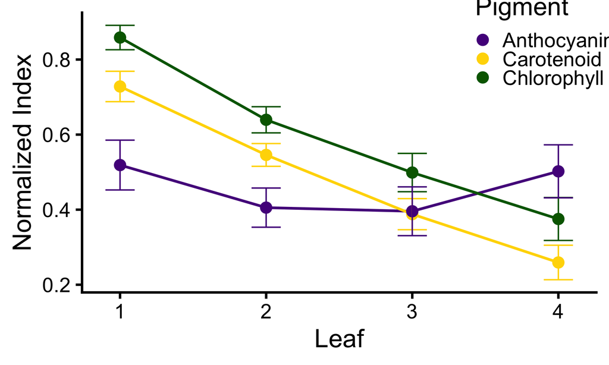

```r
base_size <- 30

p_pigments <- corncyc_summary %>%
  filter(xpindex != "flavonoids") %>%
  mutate(xpindex = tools::toTitleCase(xpindex)) %>%
  ggplot(aes(x = leaf_stage, y = mean, color = xpindex)) +
  geom_line(linewidth = 1.5) +
  geom_point(size = 5) +
  geom_errorbar(
    aes(ymin = mean - se, ymax = mean + se),
    width = 0.2,
    linewidth = 0.8
  ) +
  labs(
    x = "Leaf",
    y = "Normalized Index",
    color = "Pigment"
  ) +
  scale_color_manual(
    values = c(
      "Chlorophyll" = "darkgreen",
      "Carotenoid" = "gold",
      "Anthocyanin" = "purple4"
    )
  ) +
  theme_classic(base_size = base_size) +
  theme(legend.position = c(0.9, 0.9))

print(p_pigments)
```

```r
ggsave(
  file.path(paths$figures, "corncyc_pigment_biosynthesis_indices.png"),
  plot = p_pigments,
  width = 12,
  height = 8,
  dpi = 300
)
```

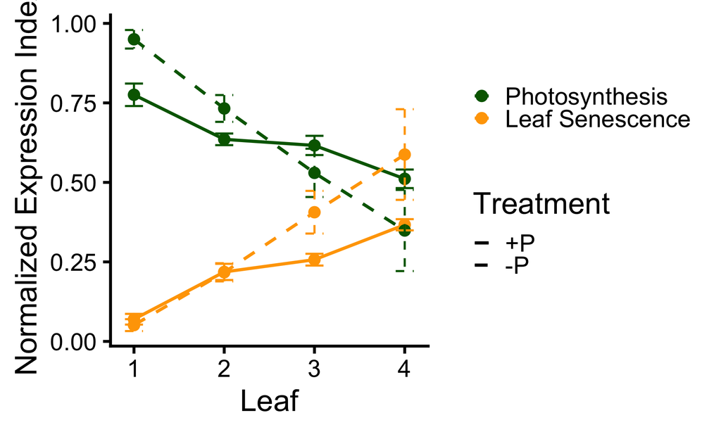

```r
p_by_treatment <- ggplot(
  xpindex_summary,
  aes(x = leaf_stage, y = mean, color = xpindex, linetype = treatment)
) +
  geom_line(linewidth = 1.5) +
  geom_point(size = 4) +
  geom_errorbar(
    aes(ymin = mean - se, ymax = mean + se),
    width = 0.2,
    linewidth = 1
  ) +
  scale_color_manual(
    values = c("Photosynthesis" = "darkgreen",
               "Leaf Senescence" = "orange")
  ) +
  scale_linetype_manual(
    values = c("+P" = "solid", "-P" = "dashed")
  ) +
  labs(
    x = "Leaf",
    y = "Normalized Expression Index",
    color = NULL,
    linetype = "Treatment"
  ) +
  theme_classic(base_size = base_size) +
  theme(legend.position = "right")

print(p_by_treatment)
```

# Main Figure: Left Panel Components

**Purpose**: Create publication-quality composite figure showing normalized xpindex, individual gene trajectories, and marker gene validation.

## Panel A: Normalized Gene Set Indices

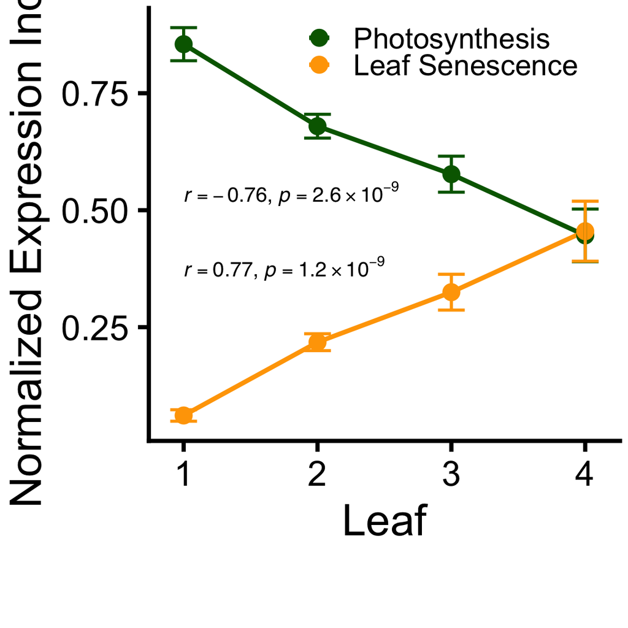

```r
xpindex_summary_pooled <- summarize_xpindex(
  xpindex_data = xpindex_norm,
  index_names = names(gene_set_list),
  group_vars = "leaf_stage"
) %>%
  mutate(
    xpindex = factor(
      tools::toTitleCase(xpindex),
      levels = c("Photosynthesis", "Senescence"),
      labels = c("Photosynthesis", "Leaf Senescence")
    )
  )

# --- Compute correlation stats ---
photo_cor <- cor.test(xpindex_norm$leaf_stage, xpindex_norm$photosynthesis, method = "pearson")
sen_cor   <- cor.test(xpindex_norm$leaf_stage, xpindex_norm$senescence,   method = "pearson")

# Format to 2 significant figures
format_2sig <- function(x) {
  x_sig <- signif(x, digits = 2)
  format(x_sig, scientific = FALSE, trim = TRUE, nsmall = 0)
}

# Create plotmath label as character string
make_label <- function(r_val, p_val) {
  r_str <- format_2sig(r_val)
  if (p_val < 0.01) {
    exp_val <- floor(log10(p_val))
    coeff  <- round(p_val / 10^exp_val, 2)
    if (coeff >= 10) {
      coeff <- coeff / 10
      exp_val <- exp_val + 1
    }
    coeff_str <- format_2sig(coeff)
    paste0("italic(r) == ", r_str, " * ',' ~ italic(p) == ", coeff_str, " %*% 10^", exp_val)
  } else {
    p_str <- format_2sig(p_val)
    paste0("italic(r) == ", r_str, " * ',' ~ italic(p) == ", p_str)
  }
}

# Build annotation data frame
annotation_df <- data.frame(
  x = 1.0,
  y = c(0.51, 0.35),  # adjust y-spacing here
  label = c(
    make_label(photo_cor$estimate, photo_cor$p.value),
    make_label(sen_cor$estimate,   sen_cor$p.value)
  ),
  stringsAsFactors = FALSE
)

# --- Plot ---
base_family <- "Helvetica"
up <- 58

p_normalized <- ggplot(
  xpindex_summary_pooled,
  aes(x = leaf_stage, y = mean, color = xpindex)
) +
  geom_line(linewidth = 1.5) +
  geom_point(size = 4) +
  geom_errorbar(
    aes(ymin = mean - se, ymax = mean + se),
    width = 0.2,
    linewidth = 1
  ) +
  scale_color_manual(
    values = c("Photosynthesis" = "darkgreen",
               "Leaf Senescence" = "orange")
  ) +
  # Single annotation layer using data frame
  geom_text(
    data = annotation_df,
    aes(x = x, y = y, label = label),
    hjust = 0,
    vjust = 0,
    size = 5,
    parse = TRUE,
    family = base_family,
    inherit.aes = FALSE
  ) +
  labs(
    x = "Leaf",
    y = "Normalized Expression Index",
    color = NULL
  ) +
  ggpubr::theme_classic2(base_size = base_size) +
  theme(
    legend.position = c(0.7, 0.9),
    legend.text = element_text(size = 20),
    legend.background = element_rect(fill = "transparent"),
    legend.margin = margin(r = 50, unit = "pt"),
    plot.margin = margin(5.5, 5.5, up, 7, "pt")
  )

print(p_normalized)
```

## Panel B: Spaghetti Plot (Individual Gene Trajectories)

```r
xp_photo_genes <- intersect(
  gene_set_list$photosynthesis,
  rownames(normalized_expression)
)

xp_photosynthesis <- normalized_expression[xp_photo_genes, ] %>%
  as.data.frame() %>%
  tibble::rownames_to_column("gene") %>%
  pivot_longer(-gene, names_to = "sample", values_to = "expression") %>%
  mutate(
    leaf_stage = as.numeric(sub(".*L([0-9]+)[LR]$", "\\1", sample))
  ) %>%
  group_by(gene) %>%
  mutate(centered_expr = expression - mean(expression)) %>%
  ungroup() %>%
  group_by(gene, leaf_stage) %>%
  summarise(mean_expr = mean(centered_expr), .groups = "drop") %>%
  arrange(gene)

xp_senescence_genes <- intersect(
  gene_set_list$senescence,
  rownames(normalized_expression)
)

xp_senescence <- normalized_expression[xp_senescence_genes, ] %>%
  as.data.frame() %>%
  tibble::rownames_to_column("gene") %>%
  pivot_longer(-gene, names_to = "sample", values_to = "expression") %>%
  mutate(
    leaf_stage = as.numeric(sub(".*L([0-9]+)[LR]$", "\\1", sample))
  ) %>%
  group_by(gene) %>%
  mutate(centered_expr = expression - mean(expression)) %>%
  ungroup() %>%
  group_by(gene, leaf_stage) %>%
  summarise(mean_expr = mean(centered_expr), .groups = "drop") %>%
  arrange(gene)

{
  cat("\n=== Spaghetti Plot Gene Counts ===\n")
  cat("Photosynthesis genes:", length(xp_photo_genes), "\n")
  cat("Senescence genes:", length(xp_senescence_genes), "\n")
}
```

```
##
## === Spaghetti Plot Gene Counts ===
## Photosynthesis genes: 165
## Senescence genes: 56
```

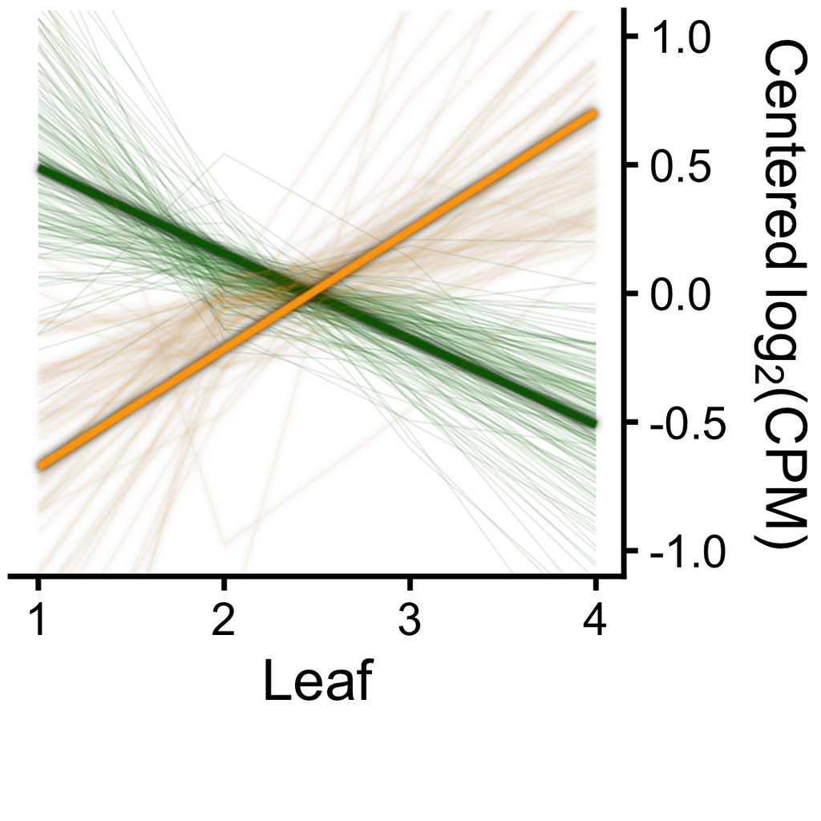

```r
p_spaghetti <- xp_photosynthesis %>%
  ggplot(aes(x = leaf_stage, y = mean_expr, group = gene)) +
  geom_line(alpha = 0.1, linewidth = 0.5, color = "darkgreen") +
  geom_smooth(
    data = xp_photosynthesis,
    aes(x = leaf_stage, y = mean_expr, group = 1),
    method = "lm",
    se = FALSE,
    linewidth = 2,
    color = "darkgreen"
  ) %>%
  with_shadow(colour = "black", x_offset = 0, y_offset = 0, sigma = 2) +
  geom_line(
    data = xp_senescence,
    aes(x = leaf_stage, y = mean_expr, group = gene),
    alpha = 0.1,
    linewidth = 0.5,
    color = "orange"
  ) %>%
  with_shadow(colour = "black", x_offset = 0, y_offset = 0, sigma = 2) +
  geom_smooth(
    data = xp_senescence,
    aes(x = leaf_stage, y = mean_expr, group = 1),
    method = "lm",
    se = FALSE,
    linewidth = 2,
    color = "orange"
  ) %>%
  with_shadow(colour = "black", x_offset = 0, y_offset = 0, sigma = 2) +
  labs(
    x = "Leaf",
    y = expression("Centered " * log[2] * "(CPM)")
  ) +
  coord_cartesian(ylim = c(-1, 1)) +
  scale_y_continuous(position = "right") +
  ggpubr::theme_classic2(base_size = base_size) +
  theme(plot.margin = margin(5.5, 7, up, 5.5, "pt"))

print(p_spaghetti)
```

## Combine Top Panels

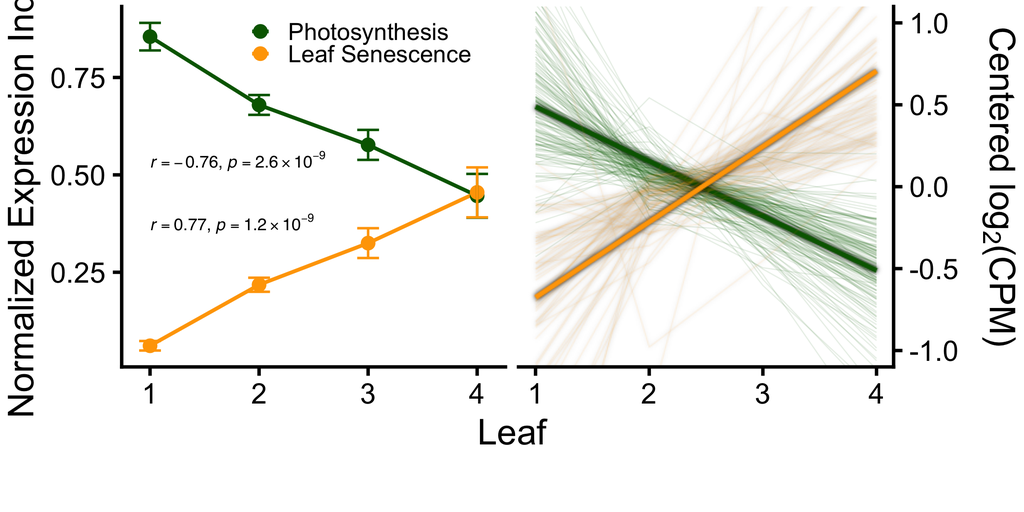

```r
p_top_panel <- ggarrange(
  p_normalized + rremove("xlab"),
  p_spaghetti + rremove("xlab"),
  ncol = 2
) %>%
  annotate_figure(
    bottom = text_grob("Leaf", size = base_size, vjust = -2)
  )

print(p_top_panel)
```

## Panel C: Marker Gene Ilustration

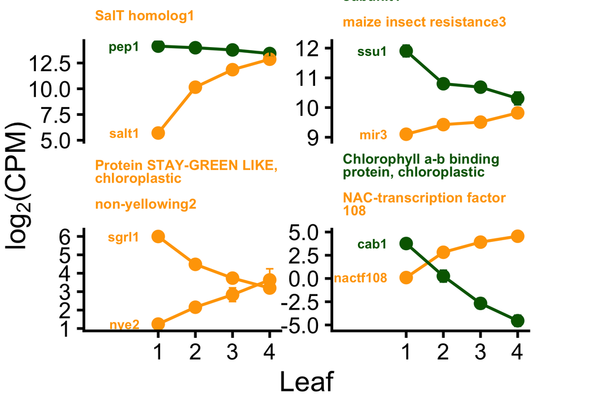

```r
marker_genes <- data.frame(
  locus_label = c("pep1", "salt1",
                  "ssu1", "mir3",
                  "nye2", "sgrl1",
                  "cab1", "dapat3"),
  gene_set = c("Photosynthesis", "Senescence",
               "Photosynthesis", "Senescence",
               "Senescence", "Senescence",
               "Photosynthesis", "Senescence"),
  pair = c("Pair1", "Pair1",
           "Pair2", "Pair2",
           "Pair3", "Pair3",
           "Pair4", "Pair4"),
  stringsAsFactors = FALSE
)


marker_genes <- data.frame(
  locus_label = c("pep1", "salt1",
                  "ssu1", "mir3",
                  "nye2", "sgrl1",
                  "cab1", "nactf108"),
  gene_set = c("Photosynthesis", "Senescence",
               "Photosynthesis", "Senescence",
               "Senescence", "Senescence",
               "Photosynthesis", "Senescence"),
  pair = c("Pair1", "Pair1",
           "Pair2", "Pair2",
           "Pair3", "Pair3",
           "Pair4", "Pair4"),
  stringsAsFactors = FALSE
)

gene_ids <- effects_df %>%
  filter(locus_label %in% marker_genes$locus_label, !is.na(locus_label)) %>%
  select(gene, locus_label, desc_merged) %>%
  distinct() %>%
  group_by(locus_label) %>%
  slice(1) %>%
  ungroup()



marker_data <- lapply(seq_len(nrow(gene_ids)), function(i) {
  g <- gene_ids$gene[i]
  data.frame(
    sample = colnames(normalized_expression),
    expression = normalized_expression[g, ],
    gene = g
  )
}) %>%
  bind_rows() %>%
  left_join(gene_ids, by = "gene") %>%
  left_join(marker_genes, by = "locus_label") %>%
  mutate(
    leaf_stage = as.numeric(sub(".*L([0-9]+)[LR]$", "\\1", sample))
  )

marker_summary <- marker_data %>%
  group_by(gene, locus_label, gene_set, desc_merged, pair, leaf_stage) %>%
  summarise(
    mean_expr = mean(expression),
    se_expr = sd(expression) / sqrt(n()),
    .groups = "drop"
  )

pair_max_expr <- marker_summary %>%
  group_by(pair) %>%
  summarise(max_expr = max(mean_expr), .groups = "drop") %>%
  arrange(desc(max_expr))

marker_summary_colored <- marker_summary %>%
  select(pair, locus_label, desc_merged, gene_set) %>%
  distinct() %>%
  mutate(
    wrapped_text = stringr::str_wrap(desc_merged, width = 25),
    with_br = gsub("\n", "<br>", wrapped_text),
    with_color = case_when(
      gene_set == "Photosynthesis" ~
        paste0("<span style='color:darkgreen'>", with_br, "</span>"),
      gene_set == "Senescence" ~
        paste0("<span style='color:orange'>", with_br, "</span>"),
      TRUE ~ with_br
    ),
    sort_order = ifelse(gene_set == "Photosynthesis", 1, 2)
  )

pair_labels <- marker_summary_colored %>%
  arrange(pair, sort_order) %>%
  group_by(pair) %>%
  summarise(
    facet_label = paste(with_color, collapse = "<br><br>"),
    .groups = "drop"
  ) %>%
  left_join(pair_max_expr, by = "pair") %>%
  arrange(desc(max_expr))

marker_summary <- marker_summary %>%
  left_join(
    pair_labels %>% select(pair, facet_label, max_expr),
    by = "pair"
  ) %>%
  mutate(
    facet_label = factor(facet_label, levels = pair_labels$facet_label)
  )

p_markers <- ggplot(
  marker_summary,
  aes(x = leaf_stage, y = mean_expr, color = gene_set, group = gene)
) +
  geom_line(linewidth = 1.5) +
  geom_point(size = 5) +
  geom_errorbar(
    aes(ymin = mean_expr - se_expr, ymax = mean_expr + se_expr),
    width = 0.2,
    linewidth = 0.8
  ) +
  geom_text(
    data = marker_summary %>% filter(leaf_stage == 1),
    aes(x = leaf_stage,
        y = mean_expr,
        label = locus_label,
        color = gene_set),
    nudge_x = -0.5,
    hjust = 1,
    fontface = "bold",
    size = 5
  ) +
  scale_color_manual(
    values = c("Photosynthesis" = "darkgreen", "Senescence" = "orange")
  ) +
  scale_x_continuous(expand = expansion(add = c(1.5, 0.2)), breaks = 1:4) +
  facet_wrap(
    ~ facet_label,
    nrow = 2,
    scales = "free_y"
  ) +
  labs(
    x = "Leaf",
    y = expression(log[2] * "(CPM)"),
    color = NULL
  ) +
  theme_classic(base_size = base_size) +
  theme(
    strip.background = element_blank(),
    strip.text = element_markdown(size = 15, hjust = 0, face = "bold"),
    plot.margin = margin(-50, 80, 5.5, 5.5, "pt"),
    axis.title.y = element_text(margin = margin(r = -10)),
    panel.spacing.x = unit(0, "cm"),
    panel.spacing.y = unit(0, "cm"),
    legend.position = "none"
  )

print(p_markers)
```

## Combine All Panels: Left Panel

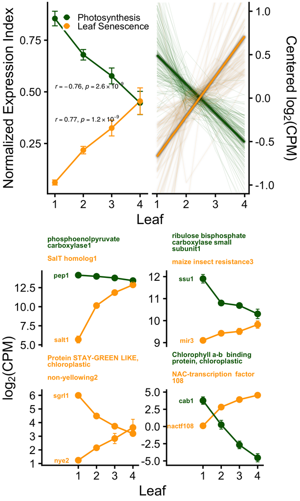

```r
left_panel <- cowplot::plot_grid(
  p_top_panel, p_markers,
  ncol = 1,
  align = 'h',
  axis = 'lr'
)

ggsave(
  file.path(paths$figures, "left_panel.png"),
  plot = left_panel,
  width = 9,
  height = 15,
  dpi = 150
)

print(left_panel)
```

# Phase 3: Statistical Analysis and Enrichment

**Purpose**: Detailed statistical models and gene set enrichment analysis.

## Statistical Models for Main Figure

```r
xpindex_models <- fit_xpindex_models(
  xpindex_data = xpindex_norm,
  index_names = names(gene_set_list),
  formula_rhs = "leaf_stage * treatment"
)

xpindex_stats <- extract_xpindex_stats(xpindex_models)

{
  cat("\n=== Expression Index Model Statistics ===\n")
  print(xpindex_stats, n = Inf)
}
```

```
##
## === Expression Index Model Statistics ===
## # A tibble: 6 × 8
##   xpindex        predictor         effect std_err p_value    r2   p_adj p_signif
##   <chr>          <chr>              <dbl>   <dbl>   <dbl> <dbl>   <dbl> <chr>
## 1 Photosynthesis leaf_stage       -0.0812  0.0203 2.67e-4 0.700 7.61e-4 ***
## 2 Photosynthesis leaf_stage:trea… -0.120   0.0309 3.81e-4 0.700 7.61e-4 ***
## 3 Photosynthesis treatment-P       0.305   0.0831 7.15e-4 0.700 1.07e-3 **
## 4 Senescence     leaf_stage        0.0930  0.0189 1.60e-5 0.715 9.60e-5 ****
## 5 Senescence     leaf_stage:trea…  0.0867  0.0288 4.57e-3 0.715 5.49e-3 **
## 6 Senescence     treatment-P      -0.129   0.0775 1.03e-1 0.715 1.03e-1 ns
```

## Supplementary Visualizations

**Purpose**: Additional exploratory plots to examine treatment effects and relationships between indices.

### Individual Index Plots by Treatment

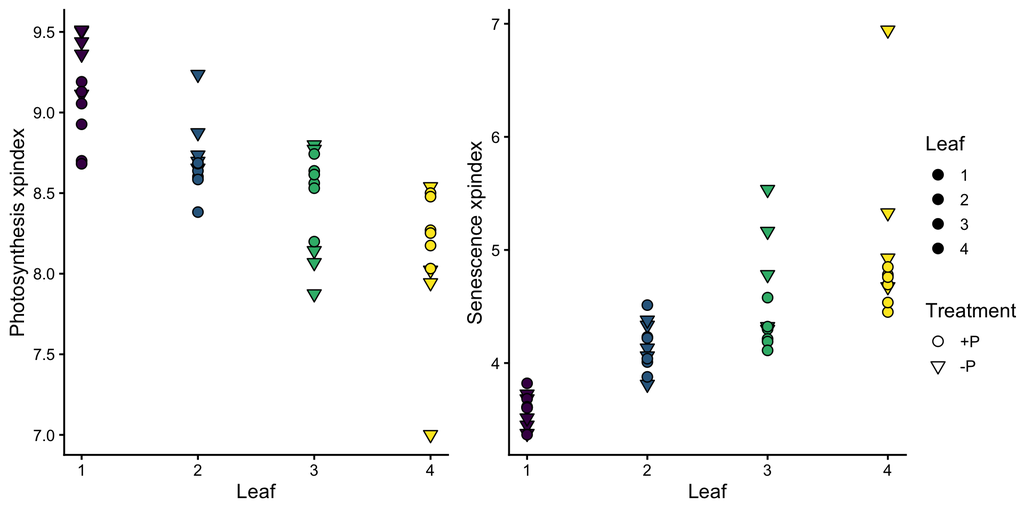

```r
p1 <- xpindex_data %>%
  ggplot(aes(
    y = photosynthesis,
    x = leaf_stage,
    fill = factor(leaf_stage),
    shape = treatment
  )) +
  geom_point(size = 3, color = "black") +
  scale_shape_manual(values = c(21, 25)) +
  scale_fill_viridis_d() +
  labs(
    x = "Leaf",
    y = "Photosynthesis xpindex",
    fill = "Leaf",
    shape = "Treatment"
  ) +
  theme_classic(base_size = 14)

p2 <- xpindex_data %>%
  ggplot(aes(
    y = senescence,
    x = leaf_stage,
    fill = factor(leaf_stage),
    shape = treatment
  )) +
  geom_point(size = 3, color = "black") +
  scale_shape_manual(values = c(21, 25)) +
  scale_fill_viridis_d() +
  labs(
    x = "Leaf",
    y = "Senescence xpindex",
    fill = "Leaf",
    shape = "Treatment"
  ) +
  theme_classic(base_size = 14)

p_individual <- ggarrange(p1, p2, ncol = 2,
                          common.legend = TRUE, legend = "right")
print(p_individual)
```

### Bivariate Relationship

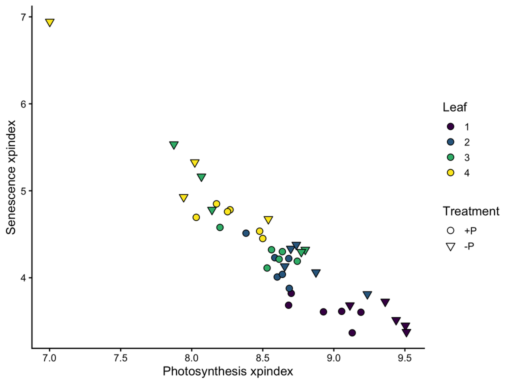

```r
p_bivariate <- xpindex_data %>%
  ggplot(aes(
    x = photosynthesis,
    y = senescence,
    fill = factor(leaf_stage),
    shape = factor(treatment)
  )) +
  geom_point(size = 3, color = "black") +
  scale_fill_viridis_d() +
  scale_shape_manual(values = c(21, 25)) +
  guides(fill = guide_legend(override.aes = list(shape = 21))) +
  labs(
    x = "Photosynthesis xpindex",
    y = "Senescence xpindex",
    fill = "Leaf",
    shape = "Treatment"
  ) +
  theme_classic(base_size = 14)

print(p_bivariate)
```

# Gene Set Enrichment Analysis

## Custom Enrichment Function

```r
#' Fisher's Exact Test for Custom Gene Set Enrichment
#'
#' @param deg_lists Named list of DEG vectors by cluster
#' @param annotation Named list of gene sets
#' @param universe Background gene set
#' @return Data frame with enrichment results
test_custom_enrichment <- function(deg_lists, annotation, universe) {
  annotation_filtered <- lapply(annotation, function(x) intersect(x, universe))
  annotation_filtered <- annotation_filtered[
    sapply(annotation_filtered, length) > 0
  ]

  results <- list()

  for (cluster_name in names(deg_lists)) {
    deg_genes <- deg_lists[[cluster_name]]

    for (term_name in names(annotation_filtered)) {
      term_genes <- annotation_filtered[[term_name]]
      overlap <- intersect(deg_genes, term_genes)

      in_both <- length(overlap)
      in_deg_only <- length(setdiff(deg_genes, term_genes))
      in_term_only <- length(setdiff(term_genes, deg_genes))
      in_neither <- length(universe) - in_both - in_deg_only - in_term_only

      contingency <- matrix(
        c(in_both, in_deg_only, in_term_only, in_neither),
        nrow = 2
      )
      fisher_result <- fisher.test(contingency, alternative = "greater")

      results[[length(results) + 1]] <- data.frame(
        Cluster = cluster_name,
        ID = term_name,
        Description = term_name,
        GeneRatio = paste0(in_both, "/", length(deg_genes)),
        BgRatio = paste0(length(term_genes), "/", length(universe)),
        pvalue = fisher_result$p.value,
        geneID = paste(overlap, collapse = "/"),
        Count = in_both,
        stringsAsFactors = FALSE
      )
    }
  }

  results_df <- do.call(rbind, results)
  results_df$p.adjust <- p.adjust(results_df$pvalue, method = "BH")

  results_df %>% arrange(p.adjust)
}

#' Extract DEG Stats for Custom Annotation
#'
#' @param annotation_id Term ID to filter
#' @param gene_term_df Data frame with gene-term mappings
#' @param effects_data DEG results
#' @param filter_strong Filter to strong DEGs
#' @return Tibble with DEG statistics
get_annotation_degs <- function(annotation_id,
                                gene_term_df,
                                effects_data,
                                filter_strong = TRUE) {
  genes_in_category <- gene_term_df %>%
    filter(ID == annotation_id) %>%
    pull(gene)

  result <- effects_data %>%
    filter(gene %in% genes_in_category)

  if (filter_strong) {
    result <- result %>% filter(is_strong_DEG)
  }

  result %>%
    select(
      predictor:gene, locus_label, desc_merged,
      logFC, neglogP, mahalanobis
    ) %>%
    group_by(predictor, regulation) %>%
    arrange(predictor, regulation, -mahalanobis) %>%
    tibble()
}
```

## Build Custom Annotation

```r
custom_annotation <- c(
  list(
    staygreen = staygreen_network$v5,
    sag = sag_orthologs_Zhang2014$v5,
    photosynthesis = gene_set_list$photosynthesis,
    leaf_senescence = gene_set_list$senescence
  ),
  natural_senescence %>%
    select(term = set, gene = v5) %>%
    distinct() %>%
    split(.$term) %>%
    lapply(function(x) x$gene)
)

{
  cat("\n=== Custom Annotation Terms ===\n")
  cat("Number of terms:", length(custom_annotation), "\n")
  print(sapply(custom_annotation, length))
}
```

```
##
## === Custom Annotation Terms ===
## Number of terms: 6
##       staygreen             sag  photosynthesis leaf_senescence         natural
##             771              48             165              56            3681
## natural_induced
##            1075
```

## Run Enrichment Tests

```r
DEGs <- with(effects_df %>% filter(is_strong_DEG), {
  list(
    Leaf.Down = unique(gene[
      predictor == "Leaf" & regulation == "Downregulated"
    ]),
    Leaf.Up = unique(gene[predictor == "Leaf" & regulation == "Upregulated"]),
    `-P.Down` = unique(gene[
      predictor == "-P" & regulation == "Downregulated"
    ]),
    `-P.Up` = unique(gene[predictor == "-P" & regulation == "Upregulated"])
  )
})

custom_enrichment_results <- test_custom_enrichment(
  DEGs,
  custom_annotation,
  universe
) %>%
  filter(p.adjust < 0.05)

{
  cat("\n=== Enrichment Results (FDR < 0.05) ===\n")
  custom_enrichment_results %>%
    select(-geneID) %>%
    print()
}
```

```
##
## === Enrichment Results (FDR < 0.05) ===
##     Cluster              ID     Description GeneRatio    BgRatio       pvalue
## 1   Leaf.Up         natural         natural   171/676 3284/24011 2.320159e-16
## 2     -P.Up         natural         natural   129/580 3284/24011 9.321672e-09
## 3   Leaf.Up leaf_senescence leaf_senescence    12/676   56/24011 4.044764e-08
## 4     -P.Up natural_induced natural_induced    53/580  991/24011 6.089533e-08
## 5   Leaf.Up natural_induced natural_induced    50/676  991/24011 5.399470e-05
## 6   Leaf.Up             sag             sag     7/676   40/24011 1.128409e-04
## 7 Leaf.Down natural_induced natural_induced    52/746  991/24011 1.723921e-04
## 8 Leaf.Down  photosynthesis  photosynthesis    11/746  165/24011 1.427648e-02
##   Count     p.adjust
## 1   171 5.568381e-15
## 2   129 1.118601e-07
## 3    12 3.235811e-07
## 4    53 3.653720e-07
## 5    50 2.591746e-04
## 6     7 4.513636e-04
## 7    52 5.910585e-04
## 8    11 4.282944e-02
```

## Gene-Level Statistics

```r
genes_in_custom_terms <- custom_enrichment_results %>%
  separate_longer_delim(geneID, delim = "/") %>%
  rename(gene = "geneID") %>%
  select(Cluster, ID, Description, gene) %>%
  inner_join(
    effects_df %>% select(gene, locus_label, desc_merged) %>% distinct(),
    by = "gene"
  )

{
  cat("\n=== Natural Senescence DEGs (Leaf effect) ===\n")
  get_annotation_degs(
    annotation_id = "natural",
    gene_term_df = genes_in_custom_terms,
    effects_data = effects_df,
    filter_strong = TRUE
  ) %>%
    filter(predictor == "Leaf") %>%
    print(n = 50)
}
```

```
##
## === Natural Senescence DEGs (Leaf effect) ===
## # A tibble: 178 × 8
##    predictor regulation gene  locus_label desc_merged  logFC neglogP mahalanobis
##    <chr>     <chr>      <chr> <chr>       <chr>        <dbl>   <dbl>       <dbl>
##  1 Leaf      Downregul… Zm00… glp1        germin-lik… -0.996    2.74        63.0
##  2 Leaf      Downregul… Zm00… <NA>        Senescence… -0.665    4.05        56.3
##  3 Leaf      Downregul… Zm00… <NA>        Phytocyani… -0.975    2.17        53.6
##  4 Leaf      Downregul… Zm00… mybr78      MYB-relate… -0.843    2.97        52.6
##  5 Leaf      Downregul… Zm00… <NA>        Inorganic … -0.841    2.10        41.6
##  6 Leaf      Downregul… Zm00… <NA>        Phospho-2-… -0.794    2.02        37.2
##  7 Leaf      Downregul… Zm00… sut7        sucrose tr… -0.805    1.46        33.0
##  8 Leaf      Upregulat… Zm00… <NA>        Cytochrome…  2.45     1.82       225.
##  9 Leaf      Upregulat… Zm00… <NA>        Indole-2-m…  2.04     3.96       152.
## 10 Leaf      Upregulat… Zm00… <NA>        Chemocyanin  1.89     1.50       133.
```

[output cut: 41 more lines]

# Export Results

```r
write.csv(
  xpindex_data,
  file = file.path(paths$intermediate, "expression_indices.csv"),
  row.names = FALSE
)

write.csv(
  custom_enrichment_results,
  file = file.path(paths$intermediate, "custom_enrichment_results.csv"),
  row.names = FALSE
)

write.csv(
  xpindex_stats,
  file = file.path(paths$intermediate, "xpindex_model_statistics.csv"),
  row.names = FALSE
)
```

# Build custom chlorophyll gene sets —

## Manually curate sets

```r
# Load CornCyc again if not in environment (safe re-load)
corncyc <- read.table(
  file.path(paths$data, "corncyc_pathways.txt"),
  sep = "\t",
  header = TRUE,
  quote = ""
)

# Extract synthesis genes: CHLOROPHYLL-SYN + PWY-5068 + PWY-5188
chloro_synthesis_genes <- corncyc %>%
  filter(Pathway.id %in% c("CHLOROPHYLL-SYN", "PWY-5068", "PWY-5188")) %>%
  pull(Protein.id) %>%
  gsub("ZM00001EB", "Zm00001eb", .) %>%
  gsub("_P\\d+$", "", ., perl = TRUE) %>%
  grep("Zm00001eb", ., value = TRUE) %>%
  unique()

# Extract degradation genes from PWY-5098
chloro_degradation_base <- corncyc %>%
  filter(Pathway.id == "PWY-5098") %>%
  pull(Protein.id) %>%
  gsub("ZM00001EB", "Zm00001eb", .) %>%
  gsub("_P\\d+$", "", ., perl = TRUE) %>%
  grep("Zm00001eb", ., value = TRUE) %>%
  unique()

# Manually add your curated degradation genes (using maizegdb_id = rownames in expression matrix)
# From Wei et al 2025
manual_degradation_genes <- c(
  "Zm00001eb307720",  # ZmCHL
  "Zm00001eb047780",  # ZmCHL2
  "Zm00001eb231810",  # ZmPPH
  "Zm00001eb103480",  # ZmSGR
  "Zm00001eb076680",  # ZmSGRL
  "Zm00001eb140370"   # ZmPAO
)

chloro_degradation_genes <- unique(c(chloro_degradation_base, manual_degradation_genes))

# Create named list
chloro_gene_sets <- list(
  chlorophyll_synthesis = chloro_synthesis_genes,
  chlorophyll_degradation = chloro_degradation_genes
)


effects_df %>%
  filter(#is_strong_DEG,
         predictor=="Leaf:-P",
         gene %in% chloro_degradation_genes) %>%
  select(gene:logFC,adj.P.Val,desc_merged) %>% tibble()
```

```
## # A tibble: 9 × 5
##   gene            locus_symbol desc_merged                       logFC adj.P.Val
##   <chr>           <chr>        <chr>                             <dbl>     <dbl>
## 1 Zm00001eb140370 phao1        pheophorbide a oxygenase1       -0.262   0.000854
## 2 Zm00001eb103480 nye2         non-yellowing2                   0.773   0.180
## 3 Zm00001eb257630 <NA>         Protein TIC 55, chloroplastic    0.149   0.259
## 4 Zm00001eb076680 <NA>         Protein STAY-GREEN LIKE, chlor… -0.0673  0.780
## 5 Zm00001eb231810 <NA>         Pheophytinase                    0.133   0.526
## 6 Zm00001eb174120 <NA>         putative methylesterase 14, ch… -0.0364  0.794
## 7 Zm00001eb027950 <NA>         Red chlorophyll catabolite red… -0.0638  0.643
## 8 Zm00001eb003760 lls1         lethal leaf spot1                0.422   0.00746
## 9 Zm00001eb047780 chph2        chlorophyllase2                  0.285   0.0105
```

## Calculate and normalize xpindex

```r
cat("=== Chlorophyll Gene Sets ===\n")
```

```
## === Chlorophyll Gene Sets ===
```

```r
cat("Synthesis genes:", length(chloro_gene_sets$chlorophyll_synthesis), "\n")
```

```
## Synthesis genes: 40
```

```r
cat("Degradation genes:", length(chloro_gene_sets$chlorophyll_degradation), "\n")
```

```
## Degradation genes: 10
```

```r
chloro_xpindex <- calculate_xpindex(
  expression_matrix = normalized_expression,
  gene_sets = chloro_gene_sets,
  method = "mean"
)
```

```
## chlorophyll_synthesis: 31/40 genes found
## chlorophyll_degradation: 9/10 genes found
```

```r
chloro_xpindex_norm <- normalize_xpindex(
  xpindex_data = chloro_xpindex,
  index_names = names(chloro_gene_sets),
  method = "per_set"
)

lm(data=chloro_xpindex,
   chlorophyll_degradation~leaf_stage*treatment ) %>%
  summary()
```

```
##
## Call:
## lm(formula = chlorophyll_degradation ~ leaf_stage * treatment,
##     data = chloro_xpindex)
##
## Residuals:
##      Min       1Q   Median       3Q      Max
## -0.40137 -0.09293  0.02659  0.05372  0.80915
##
## Coefficients:
##                        Estimate Std. Error t value Pr(>|t|)
## (Intercept)             5.38762    0.09641  55.884  < 2e-16 ***
## leaf_stage              0.06527    0.03520   1.854  0.07130 .
## treatment-P            -0.17022    0.14450  -1.178  0.24595
## leaf_stage:treatment-P  0.15017    0.05368   2.797  0.00796 **
## ---
## Signif. codes:  0 '***' 0.001 '**' 0.01 '*' 0.05 '.' 0.1 ' ' 1
##
## Residual standard error: 0.1928 on 39 degrees of freedom
## Multiple R-squared:  0.5173, Adjusted R-squared:  0.4802
## F-statistic: 13.93 on 3 and 39 DF,  p-value: 2.535e-06
```

```r
lm(data=chloro_xpindex,
   chlorophyll_synthesis~leaf_stage*treatment ) %>%
  summary()
```

```
##
## Call:
## lm(formula = chlorophyll_synthesis ~ leaf_stage * treatment,
##     data = chloro_xpindex)
##
## Residuals:
##      Min       1Q   Median       3Q      Max
## -0.32398 -0.07748  0.02540  0.09880  0.41586
##
## Coefficients:
##                        Estimate Std. Error t value Pr(>|t|)
## (Intercept)             5.36190    0.08724  61.464  < 2e-16 ***
## leaf_stage             -0.15342    0.03185  -4.816 2.23e-05 ***
## treatment-P             0.24275    0.13075   1.857   0.0709 .
## leaf_stage:treatment-P -0.11258    0.04858  -2.318   0.0258 *
## ---
## Signif. codes:  0 '***' 0.001 '**' 0.01 '*' 0.05 '.' 0.1 ' ' 1
##
## Residual standard error: 0.1745 on 39 degrees of freedom
## Multiple R-squared:  0.6606, Adjusted R-squared:  0.6345
## F-statistic:  25.3 on 3 and 39 DF,  p-value: 2.949e-09
```

## Summarize for plotting

```r
# Pooled (all leaves, ignore treatment)
summary_pooled <- summarize_xpindex(
  xpindex_data = chloro_xpindex_norm,
  index_names = names(chloro_gene_sets),
  group_vars = "leaf_stage"
) %>%
  mutate(
    xpindex = case_when(
      xpindex == "chlorophyll_synthesis" ~ "Synthesis",
      xpindex == "chlorophyll_degradation" ~ "Degradation"
    ),
    xpindex = factor(xpindex, levels = c("Synthesis", "Degradation"))
  )

# By treatment
summary_by_treatment <- summarize_xpindex(
  xpindex_data = chloro_xpindex_norm,
  index_names = names(chloro_gene_sets),
  group_vars = c("leaf_stage", "treatment")
) %>%
  mutate(
    xpindex = case_when(
      xpindex == "chlorophyll_synthesis" ~ "Synthesis",
      xpindex == "chlorophyll_degradation" ~ "Degradation"
    ),
    xpindex = factor(xpindex, levels = c("Synthesis", "Degradation"))
  )
```

## Plotting 1

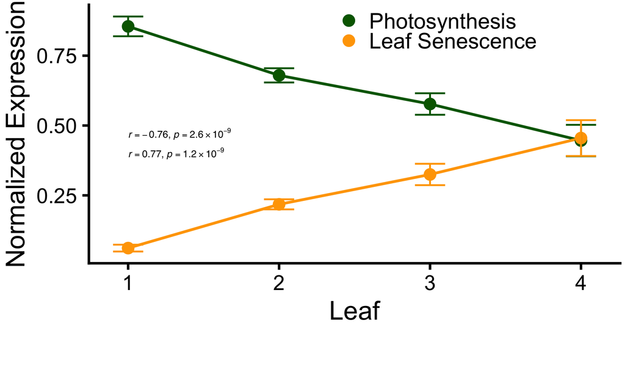

```r
# --- Correlation stats for p_normalized (Photosynthesis / Senescence) ---
photo_cor <- cor.test(
  xpindex_norm$leaf_stage,
  xpindex_norm$photosynthesis,
  method = "pearson")
sen_cor   <- cor.test(
  xpindex_norm$leaf_stage,
  xpindex_norm$senescence,
  method = "pearson")


annotation_df1 <- data.frame(
  x = 1.0,
  y = c(0.45, 0.38),
  label = c(
    make_label(photo_cor$estimate, photo_cor$p.value),
    make_label(sen_cor$estimate,   sen_cor$p.value)
  ),
  stringsAsFactors = FALSE
)

synth_cor  <- cor.test(
  chloro_xpindex_norm$leaf_stage,
  chloro_xpindex_norm$chlorophyll_synthesis,
  method = "pearson")
degrad_cor <- cor.test(
  chloro_xpindex_norm$leaf_stage,
  chloro_xpindex_norm$chlorophyll_degradation,
  method = "pearson")

annotation_df2 <- data.frame(
  x = 1.0,
  y = c(0.45, 0.38),
  label = c(
    make_label(synth_cor$estimate,  synth_cor$p.value),
    make_label(degrad_cor$estimate, degrad_cor$p.value)
  ),
  stringsAsFactors = FALSE
)

p_normalized <- ggplot(
  xpindex_summary_pooled,
  aes(x = leaf_stage, y = mean, color = xpindex)
) +
  geom_line(linewidth = 1.5) +
  geom_point(size = 5) +
  geom_errorbar(
    aes(ymin = mean - se, ymax = mean + se),
    width = 0.2,
    linewidth = 1
  ) +
  scale_color_manual(
    values = c("Photosynthesis" = "darkgreen",
               "Leaf Senescence" = "orange")
  ) +
  geom_text(
    data = annotation_df1,
    aes(x = x, y = y, label = label),
    hjust = 0,
    vjust = 0,
    size = 4,
    parse = TRUE,
    family = base_family,
    inherit.aes = FALSE
  ) +
  labs(
    x = "Leaf",
    y = "Normalized Expression",
    color = NULL
  ) +
  ggpubr::theme_classic2(base_size = base_size) +
  theme(
    legend.position = c(0.7, 0.9),
    legend.text = element_text(size = 25),
    legend.background = element_rect(fill = "transparent"),
    legend.margin = margin(r = 50, unit = "pt"),
    plot.margin = margin(5.5, 5.5, up, 7, "pt")
  )

print(p_normalized)
```

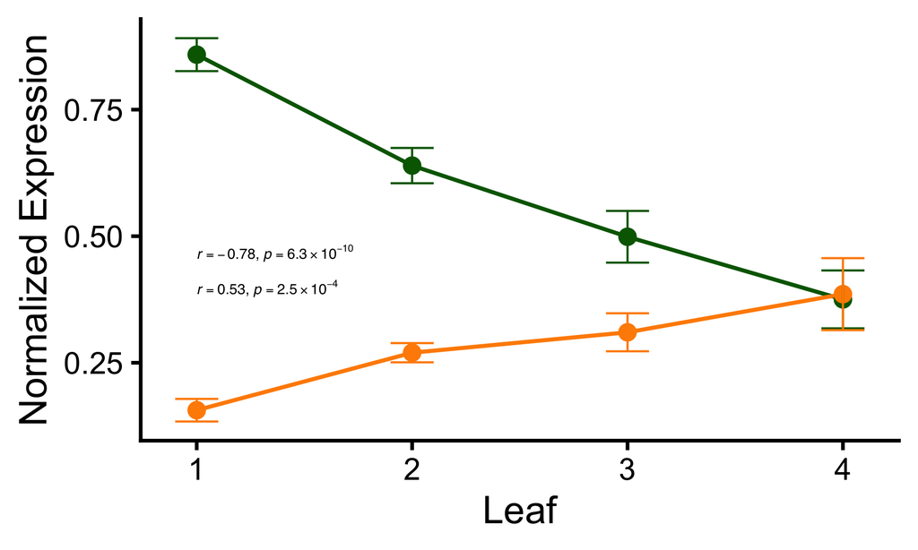

```r
# --- Plot 2: p_chloro_pooled ---
base_size <- 30

p_chloro_pooled <- summary_pooled %>%
  ggplot(aes(x = leaf_stage, y = mean, color = xpindex)) +
  geom_line(linewidth = 1.5) +
  geom_point(size = 5) +
  geom_errorbar(
    aes(ymin = mean - se, ymax = mean + se),
    width = 0.2,
    linewidth = 0.8
  ) +
  scale_color_manual(
    values = c("Synthesis" = "darkgreen",
               "Degradation" = "darkorange")
  ) +
  geom_text(
    data = annotation_df2,
    aes(x = x, y = y, label = label),
    hjust = 0,
    vjust = 0,
    size = 4,
    parse = TRUE,
    family = base_family,
    inherit.aes = FALSE
  ) +
  labs(
    y = "Normalized Expression",
    x = "Leaf",
    color = NULL
  ) +
  theme_classic(base_size = base_size) +
  theme(legend.position = "none")

print(p_chloro_pooled)
```

```r
ggsave(
  file.path(paths$figures, "chlorophyll_synthesis_vs_degradation_pooled.png"),
  plot = p_chloro_pooled,
  width = 10,
  height = 6,
  dpi = 300
)
```

## Plotting 2 joins

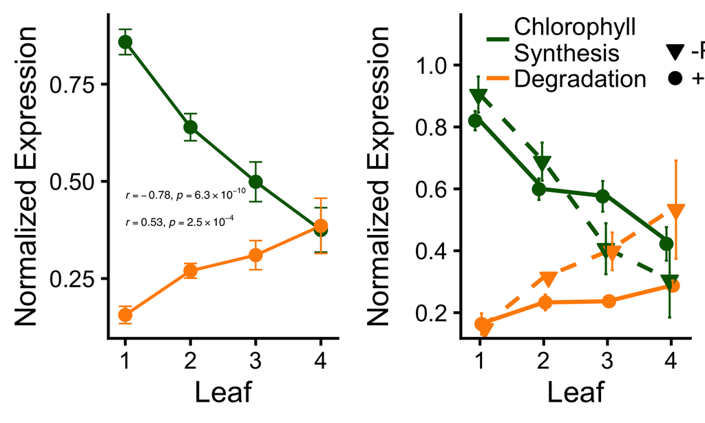

```r
pd <- position_dodge(width = 0.2)
# Plot 2: By treatment
p_chloro_treatment <- summary_by_treatment %>%
  ggplot(aes(x = leaf_stage, y = mean,
             color = xpindex,
             fill = xpindex,
             linetype = treatment,
             shape=treatment)) +
  geom_line(linewidth = 2) +
  geom_point(position = pd,
             size = 5) +
  geom_errorbar(
    aes(ymin = mean - se, ymax = mean + se),
    position = pd,
    width = 0.2,
    linewidth = 1,
    linetype = "solid",
  ) +
  scale_x_continuous(
    expand=expansion(add = c(0.2,0.2))
  ) +
  scale_y_continuous(
    expand=expansion(add = c(0,0.2)),
    breaks = 2*(0:5)/10
  ) +
  scale_color_manual(
    values = c("Synthesis" = "darkgreen",
               "Degradation" = "darkorange"),
    labels = c("Chlorophyll\nSynthesis","Degradation")
  ) +
    scale_fill_manual(
    values = c("Synthesis" = "darkgreen",
               "Degradation" = "darkorange", guide= "none")
  ) +
  scale_linetype_manual(
    values = c("+P" = "solid", "-P" = "dashed", guide= "none")
  ) +
    scale_shape_manual(
    values = c("+P" = 19, "-P" = 25)
  ) +
  labs(
    x = "Leaf",
    y = "Normalized Expression",
    color = NULL,
    shape = NULL,
  ) +
  guides(
    fill = "none",
    linetype = "none",
    shape = guide_legend(
      override.aes = list(fill = "black"),
      order = 2,
      #label.position = "left",
      #label.hjust = 1 ,
      reverse = TRUE
      ),
    color = guide_legend(
      override.aes = list(shape = NA),
      order = 1,
      # label.position = "left",
      # label.hjust = 1,
    )
  )+
  theme_classic(base_size = base_size) +
  theme(
    legend.title = element_blank(),
    legend.position = c(0.1, 1),
    legend.justification = c(0, 1),
    legend.text = element_text(
      size = 25,
      margin = margin(l =unit(2, "lines"))
      ),
    legend.box = "horizontal",
    legend.box.just = "bottom",
    legend.margin = margin(0, 0, 0, 0),
    legend.spacing.x = unit(1, "lines"),
    legend.key.spacing.x = unit(2, "lines"),
    legend.key.size = unit(2, "lines"),
    legend.key = element_rect(fill = "transparent"),
    legend.background = element_rect(fill = "transparent")
  )

 p_chloro <- ggpubr::ggarrange(p_chloro_pooled,
                              p_chloro_treatment,
                              align="hv")
p_chloro
```

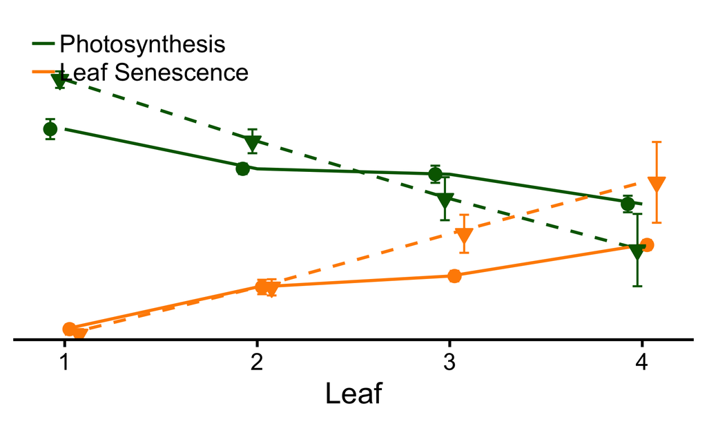

```r
ggsave(
  file.path(paths$figures, "chlorophyll_synthesis_vs_degradation_by_treatment.png"),
  plot = p_chloro,
  width = 12,
  height = 7,
  dpi = 300
)

# --- Step 1: Prepare both datasets with consistent structure ---


p_photo_sene <- xpindex_summary %>%
  ggplot(aes(x = leaf_stage, y = mean,
             color = xpindex,
             fill = xpindex,
             linetype = treatment,
             shape=treatment)) +
  geom_line(linewidth = 1.5) +
  geom_point(position = pd,
             size = 5) +
  geom_errorbar(
    aes(ymin = mean - se, ymax = mean + se),
    position = pd,
    width = 0.2,
    linewidth = 1,
    linetype = "solid",
  ) +
  scale_y_continuous(
    expand=expansion(add = c(0,0.2))
  ) +
  scale_color_manual(
    values = c("Photosynthesis" = "darkgreen",
               "Leaf Senescence" = "darkorange"),
  ) +
    scale_fill_manual(
     values = c("Photosynthesis" = "darkgreen",
               "Leaf Senescence" = "darkorange"),
     guide= "none"
  ) +
  scale_linetype_manual(
    values = c("+P" = "solid", "-P" = "dashed", guide= "none")
  ) +
    scale_shape_manual(
    values = c("+P" = 19, "-P" = 25),
    guide="none"
  ) +
  labs(
    x = "Leaf",
    y = "Normalized Expression",
    color = NULL,
    shape = NULL,
  ) +
  guides(
    fill = "none",
    linetype = "none",
    shape="none",
    color = guide_legend(
      override.aes = list(shape = NA),
      order = 1,
      #label.position = "left",
      #label.hjust = 1,
    )

  )+
  theme_classic(base_size = base_size) +
  theme(
   legend.title = element_blank(),
    legend.position = c(0, 1),
    legend.justification = c(0, 1),
    legend.text = element_text(
      size = 25,
      margin = margin(l =unit(2, "lines"))                ),
      # legend.text.align = 1,
      # legend.justification = "center",
      # legend.box.just = "right",
      # legend.margin = margin(0, 0, 0, 0),
      # legend.spacing.y = unit(0, "lines"),
      # legend.key.spacing.y = unit(0, "lines"),
    legend.key.size = unit(2, "lines"),
    legend.key = element_rect(fill = "transparent"),
      legend.background = element_rect(fill = "transparent"),
    axis.title.y = element_blank(),
    axis.text.y = element_blank(),
    axis.ticks.y = element_blank(),
    axis.line.y = element_blank()
  )

print(p_photo_sene)
```

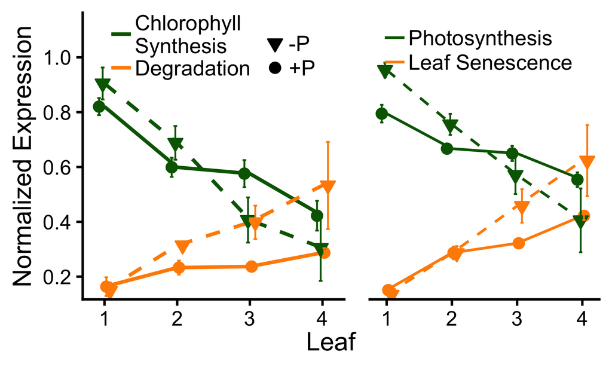

```r
p_combined_by_treatment <- ggpubr::ggarrange(
  p_chloro_treatment + rremove("xlab"),
 p_photo_sene + rremove("xlab"),
 nrow=1,
 widths= c(1.4,1)) %>%
    annotate_figure(
    bottom = text_grob("Leaf", size = base_size,
                       vjust = -0.25,
                       hjust = 0)
  )

p_combined_by_treatment
```

```r
ggsave(
  file.path(paths$figures, "combined_by_treatment_xpindex.png"),
  plot = p_combined_by_treatment,
  width = 9.25,
  height = 9,
  dpi = 150
)
```

## Pooled indices

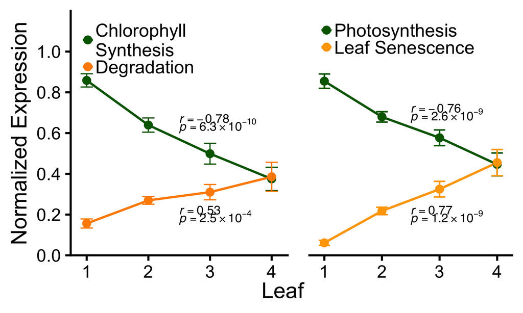

```r
# ------------------------------------------------------------
# 1. Formatting helpers (must be defined)
# ------------------------------------------------------------
# If not already defined, uncomment these:
format_2sig <- function(x) {
  x_sig <- signif(x, digits = 2)
  format(x_sig, scientific = FALSE, trim = TRUE, nsmall = 0)
}

make_p_label <- function(p_val) {
  if (p_val < 0.01) {
    exp_val <- floor(log10(p_val))
    coeff  <- round(p_val / 10^exp_val, 2)
    if (coeff >= 10) {
      coeff <- coeff / 10
      exp_val <- exp_val + 1
    }
    coeff_str <- format_2sig(coeff)
    paste0("italic(p) == ", coeff_str, " %*% 10^", exp_val)
  } else {
    p_str <- format_2sig(p_val)
    paste0("italic(p) == ", p_str)
  }
}

# ------------------------------------------------------------
# 2. Annotation data frames (one call each)
# ------------------------------------------------------------
annotation_left <- data.frame(
  x = rep(2.5, 4),
  y = c(0.65, 0.6, 0.2, 0.15),
  label = c(
    paste0("italic(r) == ", format_2sig(synth_cor$estimate)),
    make_p_label(synth_cor$p.value),
    paste0("italic(r) == ", format_2sig(degrad_cor$estimate)),
    make_p_label(degrad_cor$p.value)
  ),
  stringsAsFactors = FALSE
)

annotation_right <- data.frame(
  x = rep(2.5, 4),
  y = c(0.70, 0.65, 0.2, 0.15),
  label = c(
    paste0("italic(r) == ", format_2sig(photo_cor$estimate)),
    make_p_label(photo_cor$p.value),
    paste0("italic(r) == ", format_2sig(sen_cor$estimate)),
    make_p_label(sen_cor$p.value)
  ),
  stringsAsFactors = FALSE
)

# ------------------------------------------------------------
# 3. Common scale
# ------------------------------------------------------------
common_y_scale <- scale_y_continuous(
  limits = c(0, 1),
  breaks = seq(0, 1, by = 0.2),
  expand = expansion(add = c(0, 0.2))
)

size <- 6

# ------------------------------------------------------------
# 4. Left panel: Chlorophyll
# ------------------------------------------------------------
p_chloro_pooled_legend <- summary_pooled %>%
  ggplot(aes(x = leaf_stage, y = mean, color = xpindex)) +
  geom_line(linewidth = 1.5) +
  geom_point(size = 4) +
  geom_errorbar(aes(ymin = mean - se, ymax = mean + se), width = 0.2, linewidth = 0.8) +
  scale_color_manual(
    values = c("Synthesis" = "darkgreen", "Degradation" = "darkorange"),
    labels = c("Chlorophyll\nSynthesis", "Degradation")
  ) +
  common_y_scale +
  geom_text(
    data = annotation_left,
    aes(x = x, y = y, label = label),
    hjust = 0,
    vjust = 0,
    size = size,
    parse = TRUE,
    family = base_family,
    inherit.aes = FALSE
  ) +
  labs(x = "Leaf", y = "Normalized Expression") +
  theme_classic(base_size = base_size) +
  theme(
    legend.position = c(0, 1),
    legend.justification = c(0, 1),
    legend.text = element_text(
      size = 25,
      margin = margin(l = unit(2, "lines"))
    ),
    legend.title = element_blank(),
    legend.key = element_rect(fill = "transparent"),
    legend.background = element_rect(fill = "transparent")
  )

# ------------------------------------------------------------
# 5. Right panel: Photosynthesis & Senescence
# ------------------------------------------------------------
p_normalized_legend <- ggplot(xpindex_summary_pooled,
                              aes(x = leaf_stage, y = mean, color = xpindex)) +
  geom_line(linewidth = 1.5) +
  geom_point(size = 4) +
  geom_errorbar(aes(ymin = mean - se, ymax = mean + se), width = 0.2, linewidth = 1) +
  scale_color_manual(
    values = c("Photosynthesis" = "darkgreen", "Leaf Senescence" = "orange"),
    labels = c("Photosynthesis", "Leaf Senescence")
  ) +
  common_y_scale +
  geom_text(
    data = annotation_right,
    aes(x = x, y = y, label = label),
    hjust = 0,
    vjust = 0,
    size = size,
    parse = TRUE,
    family = base_family,
    inherit.aes = FALSE
  ) +
  labs(x = "Leaf", y = "Normalized Expression") +
  ggpubr::theme_classic2(base_size = base_size) +
  theme(
    legend.position = c(0, 1),
    legend.justification = c(0, 1),
    legend.text = element_text(
      size = 25,
      margin = margin(l = unit(2, "lines"))
    ),
    legend.title = element_blank(),
    legend.key = element_rect(fill = "transparent"),
    legend.background = element_rect(fill = "transparent"),
    axis.title.y = element_blank(),
    axis.text.y = element_blank(),
    axis.ticks.y = element_blank(),
    axis.line.y = element_blank()
  )

# ------------------------------------------------------------
# 6. Combine and save
# ------------------------------------------------------------
p_combined_pooled_separate_legends <- ggpubr::ggarrange(
  p_chloro_pooled_legend + rremove("xlab"),
  p_normalized_legend + rremove("xlab"),
  nrow = 1,
  widths = c(1.33, 1)
) %>%
  annotate_figure(
    bottom = text_grob("Leaf", size = base_size, vjust = -0.3, hjust = 0)
  )

ggsave(
  file.path(paths$figures, "combined_pooled_xpindex_separate_legends.png"),
  plot = p_combined_pooled_separate_legends,
  width = 8.2,
  height = 7,
  dpi = 150
)

print(p_combined_pooled_separate_legends)
```

## Panel C: Marker Gene Ilustration with black facet labels

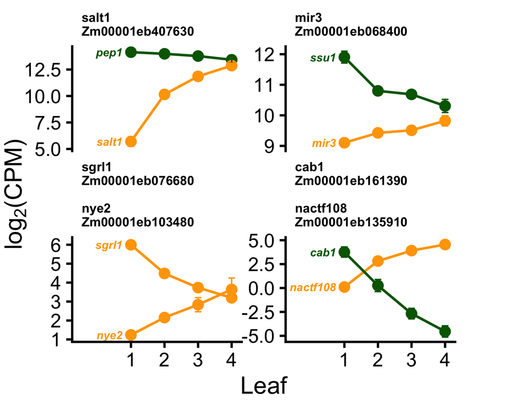

```r
marker_genes <- data.frame(
  locus_label = c("pep1", "salt1",
                  "ssu1", "mir3",
                  "nye2", "sgrl1",
                  "cab1", "nactf108"),
  gene_set = c("Photosynthesis", "Senescence",
               "Photosynthesis", "Senescence",
               "Senescence", "Senescence",
               "Photosynthesis", "Senescence"),
  pair = c("Pair1", "Pair1",
           "Pair2", "Pair2",
           "Pair3", "Pair3",
           "Pair4", "Pair4"),
  stringsAsFactors = FALSE
)

# Trim ", chloroplastic" from desc_merged in effects_df before joining
gene_ids <- effects_df %>%
  mutate(desc_merged = stringr::str_remove(desc_merged, ", chloroplastic") %>%  # <-- (1) TRIM
  stringr::str_remove( "Protein ") %>%  # <-- (1) TRIM
  stringr::str_remove(" protein")
  ) %>%
  filter(locus_label %in% marker_genes$locus_label, !is.na(locus_label)) %>%
  select(gene, locus_label, desc_merged) %>%
  distinct() %>%
  group_by(locus_label) %>%
  slice(1) %>%
  ungroup()

marker_data <- lapply(seq_len(nrow(gene_ids)), function(i) {
  g <- gene_ids$gene[i]
  data.frame(
    sample = colnames(normalized_expression),
    expression = normalized_expression[g, ],
    gene = g
  )
}) %>%
  bind_rows() %>%
  left_join(gene_ids, by = "gene") %>%
  left_join(marker_genes, by = "locus_label") %>%
  mutate(
    leaf_stage = as.numeric(sub(".*L([0-9]+)[LR]$", "\\1", sample))
  )

marker_summary <- marker_data %>%
  group_by(gene, locus_label, gene_set, desc_merged, pair, leaf_stage) %>%
  summarise(
    mean_expr = mean(expression),
    se_expr = sd(expression) / sqrt(n()),
    .groups = "drop"
  )

# Build PLAIN TEXT facet labels with line breaks and wrapped descriptions
pair_labels <- marker_summary %>%
  distinct(pair, locus_label, gene, desc_merged, gene_set) %>%
  mutate(
         facet_label = paste0(locus_label, "\n", gene),
    # Wrap ONLY the description part (e.g., width = 30)
    # wrapped_desc = stringr::str_wrap(desc_merged, width = 30),
    # Construct label: "locus gene\nwrapped description"
        # facet_label = paste0(locus_label, " ", gene, "\n", wrapped_desc),
    # trunc_desc = stringr::str_trunc(desc_merged, width = 27),
   # facet_label = paste0(locus_label, " ", gene, "\n", trunc_desc),

    order_key = ifelse(gene_set == "Photosynthesis", 1, 2)
  ) %>%
  arrange(pair, order_key) %>%
  group_by(pair) %>%
  summarise(
    facet_label = paste(facet_label, collapse = "\n\n"),  # double line break between gene entries
    .groups = "drop"
  )

# Get max expression per pair for ordering
pair_max_expr <- marker_summary %>%
  group_by(pair) %>%
  summarise(max_expr = max(mean_expr), .groups = "drop") %>%
  arrange(desc(max_expr))

# Join and set factor levels in correct order
pair_labels <- pair_labels %>%
  left_join(pair_max_expr, by = "pair") %>%
  arrange(desc(max_expr))

marker_summary <- marker_summary %>%
  left_join(pair_labels %>% select(pair, facet_label, max_expr), by = "pair") %>%
  mutate(
    facet_label = factor(facet_label, levels = pair_labels$facet_label)
  )

p_markers <- ggplot(
  marker_summary,
  aes(x = leaf_stage, y = mean_expr, color = gene_set, group = gene)
) +
  geom_line(linewidth = 1.5) +
  geom_point(size = 5) +
  geom_errorbar(
    aes(ymin = mean_expr - se_expr, ymax = mean_expr + se_expr),
    width = 0.2,
    linewidth = 0.8
  ) +
  geom_text(
    data = marker_summary %>% filter(leaf_stage == 1),
    aes(x = leaf_stage,
        y = mean_expr,
        label = locus_label,
        color = gene_set),
    nudge_x = -0.25,
    hjust = 1,
    fontface = "bold.italic",
    size = 5
  ) +
  scale_color_manual(
    values = c("Photosynthesis" = "darkgreen", "Senescence" = "orange")
  ) +
  scale_x_continuous(expand = expansion(add = c(1.5, 0.2)), breaks = 1:4) +
  facet_wrap(
    ~ facet_label,
    nrow = 2,
    scales = "free_y"
  ) +
  labs(
    x = "Leaf",
    y = expression(log[2] * "(CPM)"),
    color = NULL
  ) +
  theme_classic(base_size = base_size) +
  theme(
    strip.background = element_blank(),
    # (3) Use plain element_text with black color
    strip.text = element_text(size = 16, hjust = 0, face = "bold", color = "black"),
    plot.margin = margin(-50, 80, 5.5, 5.5, "pt"),
    axis.title.y = element_text(margin = margin(r = -10)),
    panel.spacing.x = unit(0, "cm"),
    panel.spacing.y = unit(0, "cm"),
    legend.position = "none"
  )

print(p_markers)
```

## Print left panel 2

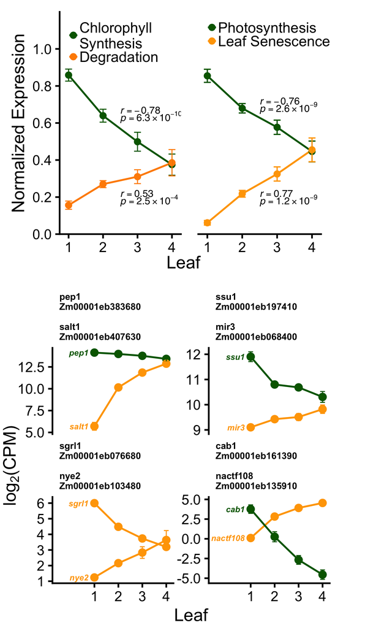

```r
left_panel <- cowplot::plot_grid(
  p_combined_pooled_separate_legends  +
  theme(plot.margin = margin(5.5, 80, up, 5.5, "pt")),
  p_markers,
  ncol = 1,
  align = 'h',
  axis = 'lr'
)

ggsave(
  file.path(paths$figures, "left_panel2.svg"),
  fix_text_size = FALSE,
  plot = left_panel,
  width = 9,
  height = 15,
  dpi = 150
)

print(left_panel)
```

## Caluclate model stats

```r
# --- Define combined gene sets ---
panel_sets <- c(chloro_gene_sets, gene_set_list)

# --- Calculate and normalize expression indices ---
panel_data <- calculate_xpindex(
  expression_matrix = normalized_expression,
  gene_sets = panel_sets,
  method = "mean"
)
```

```
## chlorophyll_synthesis: 31/40 genes found
## chlorophyll_degradation: 9/10 genes found
## photosynthesis: 165/165 genes found
## senescence: 56/56 genes found
```

```r
panel_norm <- normalize_xpindex(
  xpindex_data = panel_data,
  index_names = names(panel_sets),
  method = "per_set"
)

# --- Model 1: Full model with interaction (leaf_stage * treatment) ---
cat("=== MODEL 1: Leaf Stage × Treatment Interaction ===\n")
```

```
## === MODEL 1: Leaf Stage × Treatment Interaction ===
```

```r
panel_models_interaction <- fit_xpindex_models(
  xpindex_data = panel_norm,
  index_names = names(panel_sets),
  formula_rhs = "leaf_stage * treatment"
)

stats_interaction <- extract_xpindex_stats(panel_models_interaction)
print(stats_interaction)
```

```
## # A tibble: 12 × 8
##    xpindex              predictor  effect std_err p_value    r2   p_adj p_signif
##    <chr>                <chr>       <dbl>   <dbl>   <dbl> <dbl>   <dbl> <chr>
##  1 Chlorophyll_degrada… leaf_sta…  0.0376  0.0203 7.13e-2 0.517 8.56e-2 ns
##  2 Chlorophyll_degrada… leaf_sta…  0.0864  0.0309 7.96e-3 0.517 1.37e-2 *
##  3 Chlorophyll_degrada… treatmen… -0.0980  0.0832 2.46e-1 0.517 2.46e-1 ns
##  4 Chlorophyll_synthes… leaf_sta… -0.122   0.0253 2.23e-5 0.661 1.34e-4 ***
##  5 Chlorophyll_synthes… leaf_sta… -0.0893  0.0385 2.58e-2 0.661 3.87e-2 *
##  6 Chlorophyll_synthes… treatmen…  0.193   0.104  7.09e-2 0.661 8.56e-2 ns
##  7 Photosynthesis       leaf_sta… -0.0812  0.0203 2.67e-4 0.700 1.07e-3 **
##  8 Photosynthesis       leaf_sta… -0.120   0.0309 3.81e-4 0.700 1.14e-3 **
##  9 Photosynthesis       treatmen…  0.305   0.0831 7.15e-4 0.700 1.72e-3 **
## 10 Senescence           leaf_sta…  0.0930  0.0189 1.60e-5 0.715 1.34e-4 ***
## 11 Senescence           leaf_sta…  0.0867  0.0288 4.57e-3 0.715 9.15e-3 **
## 12 Senescence           treatmen… -0.129   0.0775 1.03e-1 0.715 1.13e-1 ns
```

```r
# --- Model 2: Additive model (leaf_stage + treatment) ---
cat("\n=== MODEL 2: Additive Effects (Leaf Stage + Treatment) ===\n")
```

```
##
## === MODEL 2: Additive Effects (Leaf Stage + Treatment) ===
```

```r
panel_models_additive <- fit_xpindex_models(
  xpindex_data = panel_norm,
  index_names = names(panel_sets),
  formula_rhs = "leaf_stage + treatment"
)

stats_additive <- extract_xpindex_stats(panel_models_additive)
print(stats_additive)
```

```
## # A tibble: 8 × 8
##   xpindex              predictor  effect std_err  p_value    r2   p_adj p_signif
##   <chr>                <chr>       <dbl>   <dbl>    <dbl> <dbl>   <dbl> <chr>
## 1 Chlorophyll_degrada… leaf_sta…  0.0747  0.0166 5.47e- 5 0.420 1.09e-4 ***
## 2 Chlorophyll_degrada… treatmen…  0.114   0.0369 3.58e- 3 0.420 5.72e-3 **
## 3 Chlorophyll_synthes… leaf_sta… -0.160   0.0201 8.73e-10 0.614 3.49e-9 ****
## 4 Chlorophyll_synthes… treatmen… -0.0267  0.0448 5.55e- 1 0.614 6.34e-1 ns
## 5 Photosynthesis       leaf_sta… -0.133   0.0178 4.22e- 9 0.584 1.12e-8 ****
## 6 Photosynthesis       treatmen…  0.0106  0.0397 7.91e- 1 0.584 7.91e-1 ns
## 7 Senescence           leaf_sta…  0.130   0.0156 2.81e-10 0.649 2.25e-9 ****
## 8 Senescence           treatmen…  0.0835  0.0348 2.13e- 2 0.649 2.84e-2 *
```

```r
# --- Model 3: Leaf stage only (pooled across treatments) ---
cat("\n=== MODEL 3: Leaf Stage Only (Pooled) ===\n")
```

```
##
## === MODEL 3: Leaf Stage Only (Pooled) ===
```

```r
panel_models_pooled <- fit_xpindex_models(
  xpindex_data = panel_norm,
  index_names = names(panel_sets),
  formula_rhs = "leaf_stage"
)

stats_pooled <- extract_xpindex_stats(panel_models_pooled)
print(stats_pooled)
```

```
## # A tibble: 4 × 8
##   xpindex              predictor  effect std_err  p_value    r2   p_adj p_signif
##   <chr>                <chr>       <dbl>   <dbl>    <dbl> <dbl>   <dbl> <chr>
## 1 Chlorophyll_degrada… leaf_sta…  0.0729  0.0182 2.52e- 4 0.282 2.52e-4 ***
## 2 Chlorophyll_synthes… leaf_sta… -0.160   0.0199 6.32e-10 0.610 2.40e-9 ****
## 3 Photosynthesis       leaf_sta… -0.133   0.0176 2.63e- 9 0.583 3.51e-9 ****
## 4 Senescence           leaf_sta…  0.129   0.0165 1.20e- 9 0.598 2.40e-9 ****
```

```r
# --- Optional: Compare models via AIC (for one example index) ---
# Example: Chlorophyll synthesis
example_index <- "chlorophyll_synthesis"
if (example_index %in% names(panel_sets)) {
  m_int <- panel_models_interaction[[example_index]]
  m_add <- panel_models_additive[[example_index]]
  m_pooled <- panel_models_pooled[[example_index]]

  cat("\n=== AIC Comparison (", example_index, ") ===\n", sep = "")
  AIC_comparison <- AIC(m_int, m_add, m_pooled)
  rownames(AIC_comparison) <- c("Interaction", "Additive", "Pooled")
  print(AIC_comparison)
}
```

```
##
## === AIC Comparison (chlorophyll_synthesis) ===
##             df       AIC
## Interaction  5 -42.23264
## Additive     4 -38.68468
## Pooled       3 -40.30490
```

```r
# --- Export results (optional) ---
# write.csv(stats_interaction, file.path(paths$intermediate, "xpindex_interaction_stats.csv"), row.names = FALSE)
# write.csv(stats_pooled, file.path(paths$intermediate, "xpindex_pooled_stats.csv"), row.names = FALSE)
```